# 4 IVIVE and POD Comparisons

### 5.4.2 MLR model for 5th%ile ToxVal

Make a simple MLR model that allows the AED50s by source to independently contribute to 5th %-ile ToxVal POD prediction.

```r
set.seed(123456)

model.aedtriage5.asnm <- lm(p5.toxval.numeric ~ 0
                 + aed50.atg
                 + aed50.bsk
                 + aed50.ccte
                 + aed50.nvs
                 + aed50.stm
                 + aed50.httr.mcf7
                 + aed50.httr.u2os
                 + aed50.httr.heparg
                 + aed50.htpp.u2os
                 + aed50.astar.beas2b
                 + aed50.astar.hepg2
                 + aed50.astar.hek293, data=asnm.tier1.pred3)
anova(model.aedtriage5.asnm)
```

|  | Df | Sum Sq | Mean Sq | F value | Pr(>F) |
| --- | --- | --- | --- | --- | --- |
| aed50.atg | 1 | 5.820547e+01 | 58.205465176 | 35.107016869 | 2.199898e-08 |
| aed50.bsk | 1 | 2.873024e+01 | 28.730243160 | 17.328838936 | 5.387167e-05 |
| aed50.ccte | 1 | 1.370752e+01 | 13.707522794 | 8.267784348 | 4.648348e-03 |
| aed50.nvs | 1 | 4.207273e-02 | 0.042072731 | 0.025376450 | 8.736558e-01 |
| aed50.stm | 1 | 1.942664e+01 | 19.426640000 | 11.717308265 | 8.065167e-04 |
| aed50.httr.mcf7 | 1 | 1.774838e+01 | 17.748378103 | 10.705053341 | 1.337351e-03 |
| aed50.httr.u2os | 1 | 4.849591e+00 | 4.849591076 | 2.925063397 | 8.936744e-02 |
| aed50.httr.heparg | 1 | 1.987018e+01 | 19.870181758 | 11.984833453 | 7.063312e-04 |
| aed50.htpp.u2os | 1 | 6.960768e+00 | 6.960767968 | 4.198433906 | 4.227691e-02 |
| aed50.astar.beas2b | 1 | 6.501511e-01 | 0.650151064 | 0.392142977 | 5.321665e-01 |

[output cut: 3 more lines]

Then evaluate the model and its assumptions.

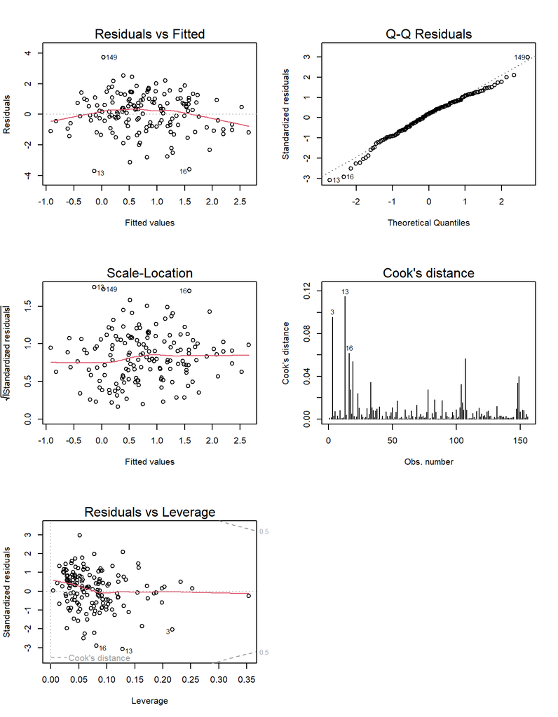

```r
par(mfrow=c(3,2))
plot(model.aedtriage5.asnm, which=c(1,2,3,4,5))
```

```r
summary(model.aedtriage5.asnm)
```

```
##
## Call:
## lm(formula = p5.toxval.numeric ~ 0 + aed50.atg + aed50.bsk +
##     aed50.ccte + aed50.nvs + aed50.stm + aed50.httr.mcf7 + aed50.httr.u2os +
##     aed50.httr.heparg + aed50.htpp.u2os + aed50.astar.beas2b +
##     aed50.astar.hepg2 + aed50.astar.hek293, data = asnm.tier1.pred3)
##
## Residuals:
##     Min      1Q  Median      3Q     Max
## -3.6871 -0.7094  0.2281  0.9493  3.7213
##
## Coefficients:
##                    Estimate Std. Error t value Pr(>|t|)
## aed50.atg          -0.04915    0.15095  -0.326  0.74519
## aed50.bsk           0.05998    0.20295   0.296  0.76800
## aed50.ccte         -0.27934    0.09508  -2.938  0.00385 **
## aed50.nvs           0.14543    0.09279   1.567  0.11921
## aed50.stm           0.06261    0.19126   0.327  0.74386
## aed50.httr.mcf7     0.01686    0.15416   0.109  0.91307
## aed50.httr.u2os    -0.49730    0.16915  -2.940  0.00382 **
## aed50.httr.heparg   0.29952    0.11776   2.544  0.01203 *
## aed50.htpp.u2os     0.54677    0.28195   1.939  0.05443 .
## aed50.astar.beas2b  0.13630    0.21069   0.647  0.51870
## aed50.astar.hepg2   0.04045    0.23734   0.170  0.86492
## aed50.astar.hek293 -0.09387    0.21771  -0.431  0.66699
## ---
## Signif. codes:  0 '***' 0.001 '**' 0.01 '*' 0.05 '.' 0.1 ' ' 1
##
## Residual standard error: 1.288 on 144 degrees of freedom
## Multiple R-squared:  0.4166, Adjusted R-squared:  0.368
## F-statistic:  8.57 on 12 and 144 DF,  p-value: 3.851e-12
```

```r
sigma(model.aedtriage5.asnm)/mean(asnm.tier1.pred3$p5.toxval.numeric)
```

```
## [1] 1.489897
```

```r
coeff.tbl <- as.data.frame(model.aedtriage5.asnm$coefficients)
coeff.tbl$var_name <- row.names(coeff.tbl)
names(coeff.tbl)[1] <- "mlr_coeff"
coeff.tbl <- as.data.table(coeff.tbl)
```

```r
asnm.tier1.pred3[,mlr.aed50.toxval5 := (coeff.tbl[var_name=="aed50.atg"]$mlr_coeff)*aed50.atg
                + (coeff.tbl[var_name=="aed50.bsk"]$mlr_coeff)*aed50.bsk
                 + (coeff.tbl[var_name=="aed50.ccte"]$mlr_coeff)*aed50.ccte
                 + (coeff.tbl[var_name=="aed50.nvs"]$mlr_coeff)*aed50.nvs
                 + (coeff.tbl[var_name=="aed50.stm"]$mlr_coeff)*aed50.stm
                 + (coeff.tbl[var_name=="aed50.httr.mcf7"]$mlr_coeff)*aed50.httr.mcf7
                 + (coeff.tbl[var_name=="aed50.httr.u2os"]$mlr_coeff)*aed50.httr.u2os
                 + (coeff.tbl[var_name=="aed50.httr.heparg"]$mlr_coeff)*aed50.httr.heparg
                 + (coeff.tbl[var_name=="aed50.htpp.u2os"]$mlr_coeff)*aed50.htpp.u2os
                 + (coeff.tbl[var_name=="aed50.astar.beas2b"]$mlr_coeff)*aed50.astar.beas2b
                 + (coeff.tbl[var_name=="aed50.astar.hepg2"]$mlr_coeff)*aed50.astar.hepg2
                 + (coeff.tbl[var_name=="aed50.astar.hek293"]$mlr_coeff)*aed50.astar.hek293]
```

### 5.4.3 MLR model for 25th%ile ToxVal

Create the linear model for the 25th %ile ToxVal POD.

```r
set.seed(123456)

model.aedtriage25.asnm <- lm(p25.toxval.numeric ~ 0
                 + aed50.atg
                 + aed50.bsk
                 + aed50.ccte
                 + aed50.nvs
                 + aed50.stm
                 + aed50.httr.mcf7
                 + aed50.httr.u2os
                 + aed50.httr.heparg
                 + aed50.htpp.u2os
                 + aed50.astar.beas2b
                 + aed50.astar.hepg2
                 + aed50.astar.hek293, data=asnm.tier1.pred3)
anova(model.aedtriage25.asnm)
```

|  | Df | Sum Sq | Mean Sq | F value | Pr(>F) |
| --- | --- | --- | --- | --- | --- |
| aed50.atg | 1 | 65.5791138 | 65.5791138 | 51.2018278 | 3.907169e-11 |
| aed50.bsk | 1 | 73.5091649 | 73.5091649 | 57.3933281 | 3.965329e-12 |
| aed50.ccte | 1 | 20.0809302 | 20.0809302 | 15.6784724 | 1.175799e-04 |
| aed50.nvs | 1 | 12.3503773 | 12.3503773 | 9.6427331 | 2.289755e-03 |
| aed50.stm | 1 | 38.4640061 | 38.4640061 | 30.0313209 | 1.850105e-07 |
| aed50.httr.mcf7 | 1 | 76.8608140 | 76.8608140 | 60.0101760 | 1.541758e-12 |
| aed50.httr.u2os | 1 | 0.8473592 | 0.8473592 | 0.6615878 | 4.173428e-01 |
| aed50.httr.heparg | 1 | 47.4582287 | 47.4582287 | 37.0536884 | 9.898644e-09 |
| aed50.htpp.u2os | 1 | 6.4025327 | 6.4025327 | 4.9988687 | 2.690222e-02 |
| aed50.astar.beas2b | 1 | 5.3875501 | 5.3875501 | 4.2064065 | 4.208447e-02 |

[output cut: 3 more lines]

Evaluate assumptions of the model.

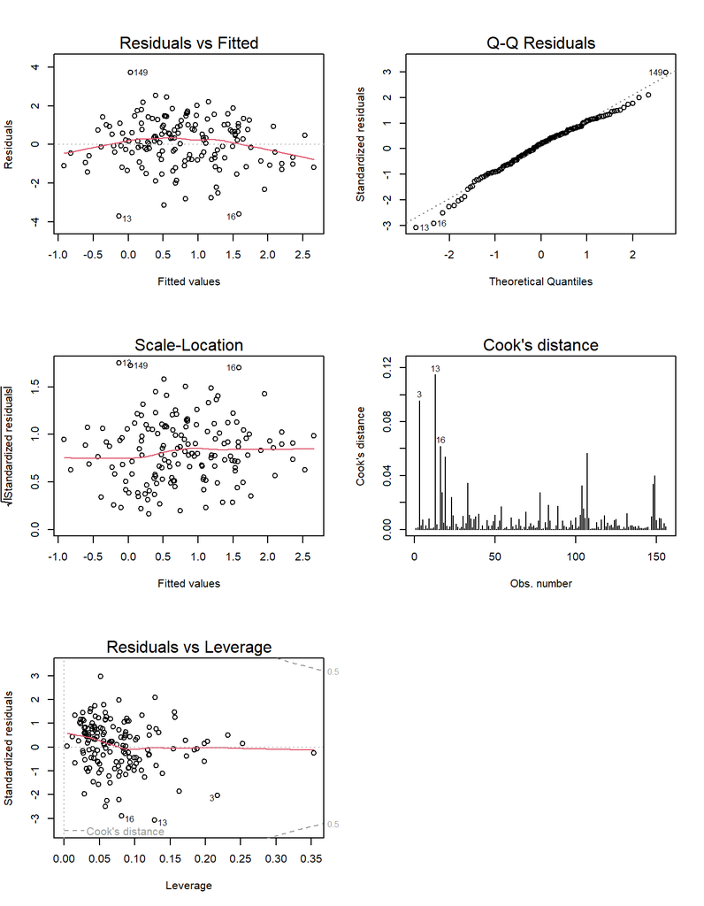

```r
par(mfrow=c(3,2))
plot(model.aedtriage5.asnm, which=c(1,2,3,4,5))
```

Summarize the model.

```r
summary(model.aedtriage25.asnm)
```

```
##
## Call:
## lm(formula = p25.toxval.numeric ~ 0 + aed50.atg + aed50.bsk +
##     aed50.ccte + aed50.nvs + aed50.stm + aed50.httr.mcf7 + aed50.httr.u2os +
##     aed50.httr.heparg + aed50.htpp.u2os + aed50.astar.beas2b +
##     aed50.astar.hepg2 + aed50.astar.hek293, data = asnm.tier1.pred3)
##
## Residuals:
##     Min      1Q  Median      3Q     Max
## -3.4419 -0.4256  0.2524  0.8404  3.4162
##
## Coefficients:
##                    Estimate Std. Error t value Pr(>|t|)
## aed50.atg          -0.08470    0.13267  -0.638 0.524244
## aed50.bsk          -0.04252    0.17838  -0.238 0.811947
## aed50.ccte         -0.29586    0.08357  -3.540 0.000539 ***
## aed50.nvs           0.02794    0.08155   0.343 0.732431
## aed50.stm          -0.15122    0.16811  -0.900 0.369844
## aed50.httr.mcf7     0.11999    0.13550   0.886 0.377318
## aed50.httr.u2os    -0.44096    0.14867  -2.966 0.003533 **
## aed50.httr.heparg   0.46609    0.10350   4.503 1.37e-05 ***
## aed50.htpp.u2os     0.44703    0.24782   1.804 0.073344 .
## aed50.astar.beas2b  0.18175    0.18518   0.981 0.328014
## aed50.astar.hepg2   0.11805    0.20861   0.566 0.572346
## aed50.astar.hek293  0.09044    0.19135   0.473 0.637176
## ---
## Signif. codes:  0 '***' 0.001 '**' 0.01 '*' 0.05 '.' 0.1 ' ' 1
##
## Residual standard error: 1.132 on 144 degrees of freedom
## Multiple R-squared:  0.6538, Adjusted R-squared:  0.6249
## F-statistic: 22.66 on 12 and 144 DF,  p-value: < 2.2e-16
```

```r
sigma(model.aedtriage5.asnm)/mean(asnm.tier1.pred3$p25.toxval.numeric)
```

```
## [1] 0.8790666
```

Build a coefficients table.

```r
coeff.tbl25 <- as.data.frame(model.aedtriage25.asnm$coefficients)
coeff.tbl25$var_name <- row.names(coeff.tbl25)
names(coeff.tbl25)[1] <- "mlr_coeff"
coeff.tbl25 <- as.data.table(coeff.tbl25)
```

Make the MLR prediction for the 25th %ile ToxVal POD using the model coefficients table.

```r
asnm.tier1.pred3[,mlr.aed50.toxval25 := (coeff.tbl25[var_name=="aed50.atg"]$mlr_coeff)*aed50.atg
                + (coeff.tbl25[var_name=="aed50.bsk"]$mlr_coeff)*aed50.bsk
                 + (coeff.tbl25[var_name=="aed50.ccte"]$mlr_coeff)*aed50.ccte
                 + (coeff.tbl25[var_name=="aed50.nvs"]$mlr_coeff)*aed50.nvs
                 + (coeff.tbl25[var_name=="aed50.stm"]$mlr_coeff)*aed50.stm
                 + (coeff.tbl25[var_name=="aed50.httr.mcf7"]$mlr_coeff)*aed50.httr.mcf7
                 + (coeff.tbl25[var_name=="aed50.httr.u2os"]$mlr_coeff)*aed50.httr.u2os
                 + (coeff.tbl25[var_name=="aed50.httr.heparg"]$mlr_coeff)*aed50.httr.heparg
                 + (coeff.tbl25[var_name=="aed50.htpp.u2os"]$mlr_coeff)*aed50.htpp.u2os
                 + (coeff.tbl25[var_name=="aed50.astar.beas2b"]$mlr_coeff)*aed50.astar.beas2b
                 + (coeff.tbl25[var_name=="aed50.astar.hepg2"]$mlr_coeff)*aed50.astar.hepg2
                 + (coeff.tbl25[var_name=="aed50.astar.hek293"]$mlr_coeff)*aed50.astar.hek293]
```

### 5.4.4 Add in MLR predictions to the prediction table

```r
asnm.tier1.pred3[, mlr.pred5 := predict(model.aedtriage5.asnm, .SD), .SDcols = c(29:41)]
asnm.tier1.pred3[, mlr.pred25 := predict(model.aedtriage25.asnm, .SD), .SDcols = c(29:40,45)]
```

Calculate the RMSE and R2 on the MLR models.

```r
mlr.eval5 <- lm(p5.toxval.numeric ~ mlr.pred5,
            data= asnm.tier1.pred3)

model.aedtriage5.asnm.rmse <- round(sqrt(mean(mlr.eval5$residuals^2)),3)
model.aedtriage5.asnm.r2 <- round(summary(mlr.eval5)$r.squared,3)

mlr.eval25 <- lm(p25.toxval.numeric ~ mlr.pred25,
            data= asnm.tier1.pred3)

model.aedtriage25.asnm.rmse <- round(sqrt(mean(mlr.eval25$residuals^2)),3)
model.aedtriage25.asnm.r2 <- round(summary(mlr.eval25)$r.squared,3)

mlr.eval25.toxval5 <- lm(p5.toxval.numeric ~ mlr.pred25,
            data= asnm.tier1.pred3)

model.aedtriage25.toxval5.rmse <- round(sqrt(mean(mlr.eval25.toxval5$residuals^2)),3)
model.aedtriage25.toxval5.r2 <- round(summary(mlr.eval25.toxval5)$r.squared,3)
```

```r
mlr.eval5 <- lm(p5.toxval.numeric ~ mlr.pred5,
            data= asnm.tier1.pred3)

model.aedtriage5.asnm.rmse <- round(sqrt(mean(mlr.eval5$residuals^2)),3)
model.aedtriage5.asnm.r2 <- round(summary(mlr.eval5)$r.squared,3)

mlr.eval25 <- lm(p25.toxval.numeric ~ mlr.pred25,
            data= asnm.tier1.pred3)

model.aedtriage25.asnm.rmse <- round(sqrt(mean(mlr.eval25$residuals^2)),3)
model.aedtriage25.asnm.r2 <- round(summary(mlr.eval25)$r.squared,3)
```

Gutcheck: look at the distribution of values from the MLR models.

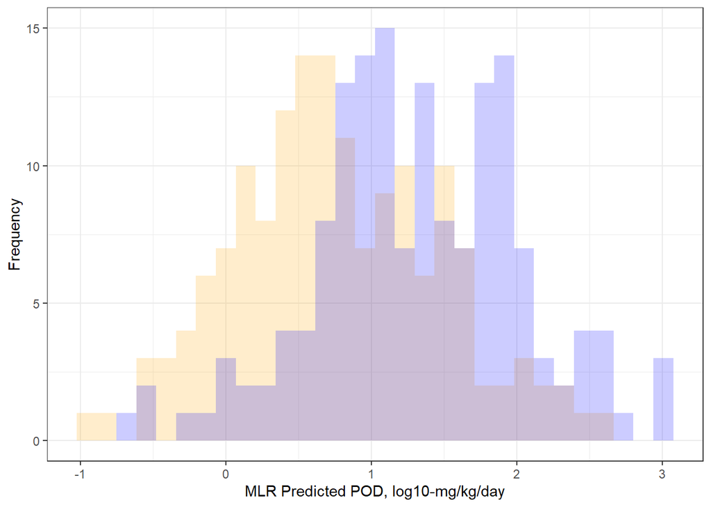

```r
ggplot(asnm.tier1.pred3)+
  geom_histogram(aes(x=asnm.tier1.pred3$mlr.pred5), fill='orange', alpha=0.2)+
  geom_histogram(aes(x=asnm.tier1.pred3$mlr.pred25), fill='blue', alpha=0.2)+
  theme_bw()+
  scale_x_continuous(breaks=seq(-2,6,1))+
  xlab("MLR Predicted POD, log10-mg/kg/day")+
  ylab("Frequency")
```

I tried adding in RF models for 5th and 25th percentile ToxVal POD. However what you find is how inappropriate it is to use the RF model to predict the data it was trained on. The performance values are artificially inflated and not very meaningful.

```r
asnm.tier1.pred3[, rf.pred5 := predict(rf_aedtriage5, .SD), .SDcols = c(29:41)]
asnm.tier1.pred3[, rf.pred25 := predict(rf_aedtriage25, .SD), .SDcols = c(29:40,45)]
asnm.tier1.pred3[,c('rf.pred5',
                     'rf.pred25'):= NULL]
```

Add in the min and med of the broad and targeted NAMs to the predictions table.

```r
# Calculate median of targeted NAMs
asnm.tier1.pred3[,med.targeted.aed50 := median(aed50.atg,
aed50.bsk, aed50.nvs, aed50.stm, na.rm=TRUE), by=c('dsstox_substance_id')]

# Calculate minimum of targeted NAMs
asnm.tier1.pred3[,min.targeted.aed50 := min(aed50.atg,
aed50.bsk, aed50.nvs, aed50.stm, na.rm=TRUE), by=c('dsstox_substance_id')]

# Calculate median of broad NAMs
asnm.tier1.pred3[,med.broad.aed50 := median(aed50.httr.mcf7,
aed50.httr.u2os, aed50.httr.heparg, aed50.htpp.u2os, na.rm=TRUE), by=c('dsstox_substance_id')]

# Calculate minimum of targeted NAMs
asnm.tier1.pred3[,min.broad.aed50 := min(aed50.httr.mcf7,
aed50.httr.u2os, aed50.httr.heparg, aed50.htpp.u2os, na.rm=TRUE), by=c('dsstox_substance_id')]
```

# 6 Visualization and Comparison

## 6.1 AED50 by source VS. ToxVal PODs

Need longformat of all AED50 values by source and ToxVal PODs.

```r
asnm.tier1.pred3.long <- melt.data.table(asnm.tier1.pred3,
                                         id.vars = c('dsstox_substance_id',
                                                     'p5.toxval.numeric',
                                                     'p25.toxval.numeric',
                                                     'p5.toxval.numeric.sub',
                                                     'p25.toxval.numeric.sub'),
                                         measure.vars = c('aed50.atg',
                                                          'aed50.bsk',
                                                          'aed50.ccte',
                                                          'aed50.nvs',
                                                          'aed50.stm',
                                                          'aed50.httr.mcf7',
                                                          'aed50.httr.u2os',
                                                          'aed50.httr.heparg',
                                                          'aed50.htpp.u2os',
                                                          'aed50.astar.beas2b',
                                                          'aed50.astar.hepg2',
                                                          'aed50.astar.hek293'),
                                         variable.name = c('aed50.type'),
                                         value.name = c('aed50'))

asnm.tier1.pred3.long <- melt.data.table(asnm.tier1.pred3.long,
                                         id.vars=c('dsstox_substance_id',
                                                   'aed50.type',
                                                   'aed50'),
                                         measure.vars=c('p5.toxval.numeric',
                                                     'p25.toxval.numeric',
                                                     'p5.toxval.numeric.sub',
                                                     'p25.toxval.numeric.sub'),
                                         variable.name=c('pod.type'),
                                         value.name = c('pod'))
```

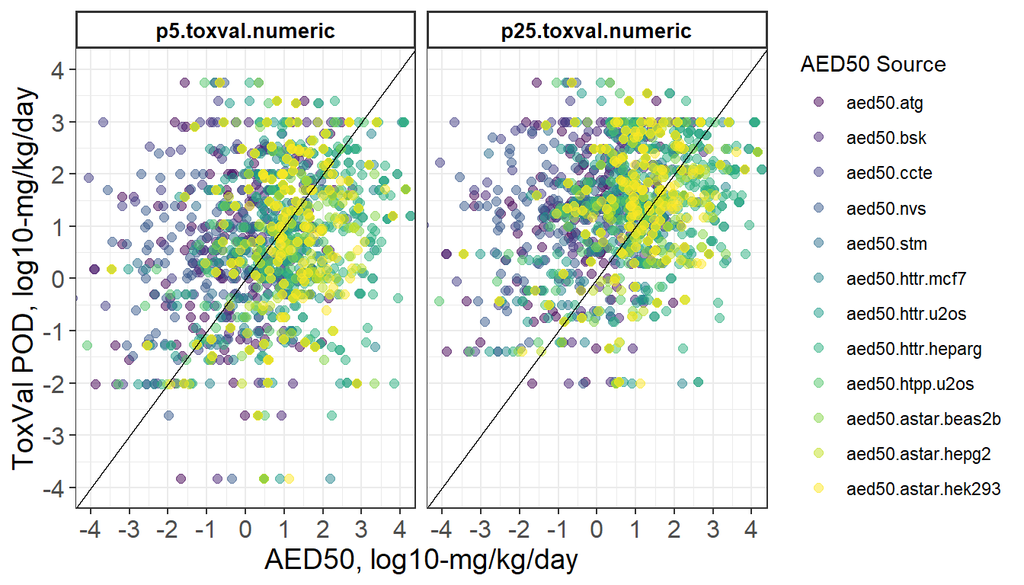

```r
aed.asnm.lm <- ggplot(data=asnm.tier1.pred3.long[pod.type %in% c('p5.toxval.numeric','p25.toxval.numeric')],
                 aes(x=aed50, y=pod, color=aed50.type))+
  geom_point(aes(x=aed50, y=pod, color=aed50.type), alpha=0.5, size=2)+
  scale_color_viridis(discrete=TRUE, name='AED50 Source')+
  scale_x_continuous(breaks=seq(-7, 5, 1))+
  scale_y_continuous(breaks=seq(-7, 5, 1))+
  coord_cartesian(xlim=c(-4,4), ylim=c(-4,4))+
  #coord_cartesian(xlim=c(0.0001, 10000000000), ylim=c(0.0000001, 10000000000))+
  theme_bw()+
  #geom_smooth(method='lm',se=FALSE,color='blue',formula=y~x)+
  #stat_poly_eq(formula=y ~x,
  #             eq.with.lhs = "y~`=`~",
  #             aes(label=paste0("atop(", ..eq.label.., ",", ..rr.label.., ")")),
  #             parse=TRUE)+
  geom_abline(color='black')+
  xlab('AED50, log10-mg/kg/day')+
  ylab('ToxVal POD, log10-mg/kg/day')+
   theme(axis.text = element_text(size=12),
        axis.title = element_text(size=14))+
  #geom_smooth(method='lm',se=FALSE,color='blue',formula=y~x)+
  #stat_poly_eq(formula=y ~x,
  #             eq.with.lhs = "italic(hat(y))~`=`~",
  #             aes(label=paste(..eq.label.., ..rr.label.., sep ="~~~")),
  #             parse=TRUE)+
  facet_wrap(~pod.type, scales='fixed')+
  theme(strip.background = element_rect(fill='white',size=1),
        strip.text = element_text(size=10, color='black',face='bold'))

aed.asnm.lm
```

## Min, Med, MLR, RF

Need longformat of all AED50 values by source and ToxVal PODs.

```r
asnm.tier1.pred3.long2 <- melt.data.table(asnm.tier1.pred3,
                                         id.vars = c('dsstox_substance_id',
                                                     'p5.toxval.numeric',
                                                     'p25.toxval.numeric'),
                                         measure.vars = c('min.aed50',
                                                          'med.aed50',
                                                          'mlr.pred5',
                                                          'mlr.pred25',
                                                          'min.targeted.aed50',
                                                          'min.broad.aed50',
                                                          'med.targeted.aed50',
                                                          'med.broad.aed50'),
                                         variable.name = c('model.type'),
                                         value.name = c('model.value'))

asnm.tier1.pred3.long2 <- melt.data.table(asnm.tier1.pred3.long2,
                                         id.vars=c('dsstox_substance_id',
                                                   'model.type',
                                                   'model.value'),
                                         measure.vars=c('p5.toxval.numeric',
                                                     'p25.toxval.numeric'),
                                         variable.name=c('pod.type'),
                                         value.name = c('pod'))
```

Add in RMSD calculation to augment RMSE and R2 from linear comparisons.

```r
rmsd <- function(x,y){
  # # check whether the length of the vectors being compared is different
  if(length(x)!=length(y)){
    stop("Length of x and y differ. Note elements should be matched pairs")
  }
  # obtain the difference between x and y
  d <- y - x
  # remove any cases where the difference is NA
  if(any(is.na(d))==TRUE){d <- d[-which(is.na(d))]}
  # obtain the root mean squared difference (RMSD)
  out <- sqrt(mean(d^2))
  # return the results
  return(out)
}
```

```r
rmsd.summary <- asnm.tier1.pred3 %>%
  dplyr::summarise(.data = .,
                   rmsd_p5_min = rmsd(min.aed50, p5.toxval.numeric),
                   rmsd_p10_min = rmsd(min.aed50, p10.toxval.numeric),
                   rmsd_p15_min = rmsd(min.aed50, p15.toxval.numeric),
                   rmsd_p20_min = rmsd(min.aed50, p20.toxval.numeric),
                   rmsd_p25_min = rmsd(min.aed50, p25.toxval.numeric),
                   rmsd_p30_min = rmsd(min.aed50, p30.toxval.numeric),

                   rmsd_p5_med = rmsd(med.aed50, p5.toxval.numeric),
                   rmsd_p10_med = rmsd(med.aed50, p10.toxval.numeric),
                   rmsd_p15_med = rmsd(med.aed50, p15.toxval.numeric),
                   rmsd_p20_med = rmsd(med.aed50, p20.toxval.numeric),
                   rmsd_p25_med = rmsd(med.aed50, p25.toxval.numeric),
                   rmsd_p30_med = rmsd(med.aed50, p30.toxval.numeric),

                   rmsd_p5_min_broad = rmsd(min.broad.aed50, p5.toxval.numeric),
                   rmsd_p10_min_broad = rmsd(min.broad.aed50, p10.toxval.numeric),
                   rmsd_p15_min_broad = rmsd(min.broad.aed50, p15.toxval.numeric),
                   rmsd_p20_min_broad = rmsd(min.broad.aed50, p20.toxval.numeric),
                   rmsd_p25_min_broad = rmsd(min.broad.aed50, p25.toxval.numeric),
                   rmsd_p30_min_broad = rmsd(min.broad.aed50, p30.toxval.numeric),

                   rmsd_p5_min_targ = rmsd(min.targeted.aed50, p5.toxval.numeric),
                   rmsd_p10_min_targ = rmsd(min.targeted.aed50, p10.toxval.numeric),
                   rmsd_p15_min_targ = rmsd(min.targeted.aed50, p15.toxval.numeric),
                   rmsd_p20_min_targ = rmsd(min.targeted.aed50, p20.toxval.numeric),
                   rmsd_p25_min_targ = rmsd(min.targeted.aed50, p25.toxval.numeric),
                   rmsd_p30_min_targ = rmsd(min.targeted.aed50, p30.toxval.numeric),

                   rmsd_p5_med_broad = rmsd(med.broad.aed50, p5.toxval.numeric),
                   rmsd_p10_med_broad = rmsd(med.broad.aed50, p10.toxval.numeric),
                   rmsd_p15_med_broad = rmsd(med.broad.aed50, p15.toxval.numeric),
                   rmsd_p20_med_broad = rmsd(med.broad.aed50, p20.toxval.numeric),
                   rmsd_p25_med_broad = rmsd(med.broad.aed50, p25.toxval.numeric),
                   rmsd_p30_med_broad = rmsd(med.broad.aed50, p30.toxval.numeric),

                   rmsd_p5_med_targ = rmsd(med.targeted.aed50, p5.toxval.numeric),
                   rmsd_p10_med_targ = rmsd(med.targeted.aed50, p10.toxval.numeric),
                   rmsd_p15_med_targ = rmsd(med.targeted.aed50, p15.toxval.numeric),
                   rmsd_p20_med_targ = rmsd(med.targeted.aed50, p20.toxval.numeric),
                   rmsd_p25_med_targ = rmsd(med.targeted.aed50, p25.toxval.numeric),
                   rmsd_p30_med_targ = rmsd(med.targeted.aed50, p30.toxval.numeric),

                   rmsd_p5_atg = rmsd(aed50.atg, p5.toxval.numeric),
                   rmsd_p5_bsk = rmsd(aed50.bsk, p5.toxval.numeric),
                   rmsd_p5_nvs = rmsd(aed50.nvs, p5.toxval.numeric),
                   rmsd_p5_stm = rmsd(aed50.stm, p5.toxval.numeric),

                   rmsd_p5_htpp_u2os = rmsd(aed50.htpp.u2os, p5.toxval.numeric),
                   rmsd_p5_httr_heparg = rmsd(aed50.httr.heparg, p5.toxval.numeric),
                   rmsd_p5_httr_mcf7 = rmsd(aed50.httr.mcf7, p5.toxval.numeric),
                   rmsd_p5_httr_u2os = rmsd(aed50.httr.u2os, p5.toxval.numeric),

                   rmsd_p5_astar_beas2b = rmsd(aed50.astar.beas2b, p5.toxval.numeric),
                   rmsd_p5_astar_hek293 = rmsd(aed50.astar.hek293, p5.toxval.numeric),
                   rmsd_p5_astar_hepg2 = rmsd(aed50.astar.hepg2, p5.toxval.numeric),

                   rmsd_p5_mlr5 = rmsd(mlr.aed50.toxval5, p5.toxval.numeric),
                   rmsd_p25_mlr25 = rmsd(mlr.aed50.toxval25, p25.toxval.numeric)
                   )

rmsd.summary <-  t(rmsd.summary) %>% as.data.frame()
rmsd.summary <- rownames_to_column(rmsd.summary, var="RMSD type")
rmsd.summary <- rename(rmsd.summary, RMSD = V1)

rmsd.summary
```

| RMSD type | RMSD |
| --- | --- |
| rmsd_p5_min | 2.226491 |
| rmsd_p10_min | 2.325810 |
| rmsd_p15_min | 2.432836 |
| rmsd_p20_min | 2.529251 |
| rmsd_p25_min | 2.624953 |
| rmsd_p30_min | 2.689353 |
| rmsd_p5_med | 1.782160 |
| rmsd_p10_med | 1.802955 |
| rmsd_p15_med | 1.852540 |
| rmsd_p20_med | 1.899632 |

[output cut: 39 more lines]

Create a summary table of model with R2 and RMSE. Modified significantly at R1 to add in more models and more easily calculate RMSE and R2.

```r
# develop model list for functions

model_list <- list(
          # battery min models
          aed.toxval5,
          aed.toxval10,
          aed.toxval15,
          aed.toxval20,
          aed.toxval25,
          aed.toxval30,

          # battery med models
          aedmed.toxval5,
          aedmed.toxval10,
          aedmed.toxval15,
          aedmed.toxval20,
          aedmed.toxval25,
          aedmed.toxval30,

          # min broad battery
          aedminbroad.toxval5,
          aedminbroad.toxval10,
          aedminbroad.toxval15,
          aedminbroad.toxval20,
          aedminbroad.toxval25,
          aedminbroad.toxval30,

          # min targeted battery
          aedmintargeted.toxval5,
          aedmintargeted.toxval10,
          aedmintargeted.toxval15,
          aedmintargeted.toxval20,
          aedmintargeted.toxval25,
          aedmintargeted.toxval30,

          # med broad battery
          aedmedbroad.toxval5,
          aedmedbroad.toxval10,
          aedmedbroad.toxval15,
          aedmedbroad.toxval20,
          aedmedbroad.toxval25,
          aedmedbroad.toxval30,

          # med targeted battery
          aedmedtargeted.toxval5,
          aedmedtargeted.toxval10,
          aedmedtargeted.toxval15,
          aedmedtargeted.toxval20,
          aedmedtargeted.toxval25,
          aedmedtargeted.toxval30,

          # individ assay models
          aedatg.toxval5,
          aedbsk.toxval5,
          aednvs.toxval5,
          aedstm.toxval5,

          aedhtpp.toxval5,
          aedhttrheparg.toxval5,
          aedhttrmcf7.toxval5,
          aedhttru2os.toxval5,

          aedastarbeas2b.toxval5,
          aedastarhek293.toxval5,
          aedastarhepg2.toxval5,


          # battery mlr models
          mlr.eval5,
          mlr.eval25,
          mlr.eval25.toxval5)


# function to calculate RMSE

model_list_rmse <- function(model) {
  round(sqrt(mean(model$residuals^2)),3)
}

# function to calculate R-squared

model_list_r2 <- function(model) {
  round(summary(model)$r.squared,3)
}

# apply rmse and r2 functions to list

models_rmse <- model_list %>% {
  tibble(rmse = map_dbl(., model_list_rmse))}

models_r2 <- model_list %>% {
  tibble(r2 = map_dbl(., model_list_r2))}
```

```r
# add in model name
models_names <- c('min AED50',
                'min AED50',
                'min AED50',
                'min AED50',
                'min AED50',
                'min AED50',
                'med AED50',
                'med AED50',
                'med AED50',
                'med AED50',
                'med AED50',
                'med AED50',

                # adding for R1: broad vs targeted parts of the battery
                'min AED50, broad',
                'min AED50, broad',
                'min AED50, broad',
                'min AED50, broad',
                'min AED50, broad',
                'min AED50, broad',
                'min AED50, targeted',
                'min AED50, targeted',
                'min AED50, targeted',
                'min AED50, targeted',
                'min AED50, targeted',
                'min AED50, targeted',

                'med AED50, broad',
                'med AED50, broad',
                'med AED50, broad',
                'med AED50, broad',
                'med AED50, broad',
                'med AED50, broad',
                'med AED50, targeted',
                'med AED50, targeted',
                'med AED50, targeted',
                'med AED50, targeted',
                'med AED50, targeted',
                'med AED50, targeted',

                # adding for R1: each assay technology in isolation
                'ATG AED50', #1
                'BSK AED50', #2
                'NVS AED50', #3
                'STM AED50', #4
                'HTPP U2-OS AED50', #5

                'HTTr HepaRG AED50',#6
                'HTTr MCF7 AED50',#7
                'HTTr U2-OS AED50',#8

                'ASTAR BEAS-2B AED50', #9
                'ASTAR HepG2 AED50',#10
                'ASTAR HK-2 AED50',#11

                'mlr AED50 trained to ToxVal5',
                'mlr AED50 trained to ToxVal25',
                'mlr AED50 trained to ToxVal25 eval ToxVal5' )
```

```r
pod.type <- c('ToxVal 5th%ile', # min battery
              'ToxVal 10th%ile',
              'ToxVal 15th%ile',
              'ToxVal 20th%ile',
              'ToxVal 25th%ile',
              'ToxVal 30th%ile',

              'ToxVal 5th%ile', # med battery
              'ToxVal 10th%ile',
              'ToxVal 15th%ile',
              'ToxVal 20th%ile',
              'ToxVal 25th%ile',
              'ToxVal 30th%ile',

              'ToxVal 5th%ile', # min broad
              'ToxVal 10th%ile',
              'ToxVal 15th%ile',
              'ToxVal 20th%ile',
              'ToxVal 25th%ile',
              'ToxVal 30th%ile',

              'ToxVal 5th%ile', # min targeted
              'ToxVal 10th%ile',
              'ToxVal 15th%ile',
              'ToxVal 20th%ile',
              'ToxVal 25th%ile',
              'ToxVal 30th%ile',

              'ToxVal 5th%ile', # med broad
              'ToxVal 10th%ile',
              'ToxVal 15th%ile',
              'ToxVal 20th%ile',
              'ToxVal 25th%ile',
              'ToxVal 30th%ile',

              'ToxVal 5th%ile', # med targeted
              'ToxVal 10th%ile',
              'ToxVal 15th%ile',
              'ToxVal 20th%ile',
              'ToxVal 25th%ile',
              'ToxVal 30th%ile',

              'ToxVal 5th%ile', #1
              'ToxVal 5th%ile', #2
              'ToxVal 5th%ile', #3
              'ToxVal 5th%ile',#4
              'ToxVal 5th%ile',#5
              'ToxVal 5th%ile',#6
              'ToxVal 5th%ile',#7
              'ToxVal 5th%ile',#8
              'ToxVal 5th%ile',#9
              'ToxVal 5th%ile',#10
              'ToxVal 5th%ile',#11

               'ToxVal 5th%ile',
              'ToxVal 25th%ile',
              'ToxVal 5th%ile'

              )
```

Bind all and neaten the dataframe

```r
# bind
rmsd.summary <- rbind(rmsd.summary, c('mlr_toxval25_vp5', NA))
models_performance_summary <- as.data.table(bind_cols(models_rmse, models_r2, rmsd.summary, models_names, pod.type))
setcolorder(models_performance_summary, c('...5','...6','rmse','r2','RMSD','RMSD type'))
setnames(models_performance_summary, c('...5','...6','rmse','r2'), c('Model Type', 'POD Type','RMSE','R2'))

models_performance_summary[,RMSD := as.numeric(RMSD)]
models_performance_summary[, RMSD := round(RMSD,3)]
models_performance_summary
```

| Model Type | POD Type | RMSE | R2 | RMSD | RMSD type |
| --- | --- | --- | --- | --- | --- |
| min AED50 | ToxVal 5th%ile | 1.264 | 0.149 | 2.226 | rmsd_p5_min |
| min AED50 | ToxVal 10th%ile | 1.201 | 0.151 | 2.326 | rmsd_p10_min |
| min AED50 | ToxVal 15th%ile | 1.138 | 0.154 | 2.433 | rmsd_p15_min |
| min AED50 | ToxVal 20th%ile | 1.091 | 0.154 | 2.529 | rmsd_p20_min |
| min AED50 | ToxVal 25th%ile | 1.039 | 0.149 | 2.625 | rmsd_p25_min |
| min AED50 | ToxVal 30th%ile | 0.998 | 0.153 | 2.689 | rmsd_p30_min |
| med AED50 | ToxVal 5th%ile | 1.278 | 0.130 | 1.782 | rmsd_p5_med |
| med AED50 | ToxVal 10th%ile | 1.207 | 0.142 | 1.803 | rmsd_p10_med |
| med AED50 | ToxVal 15th%ile | 1.143 | 0.147 | 1.853 | rmsd_p15_med |
| med AED50 | ToxVal 20th%ile | 1.089 | 0.157 | 1.900 | rmsd_p20_med |

[output cut: 40 more lines]

Here we write the final models performance table.

```r
# from rf_aedtriage5
rf_mod_toxval5 <- t(as.data.frame(c('rf AED50','ToxVal 5th%ile',1.273,0.171,NA,NA)))
# from rf_aedtriage25
rf_mod_toxval25 <- t(as.data.frame(c('rf AED50','ToxVal 25th%ile',1.031,0.206,NA,NA)))

models_performance_summary <- rbind(models_performance_summary,
                                    rf_mod_toxval5,
                                    rf_mod_toxval25,
                                    use.names=FALSE)

#write.csv(models_performance_summary, './output/Table2_models_performance_summary_27nov2024.csv')
```

This next part is a summary visualization of some of the models for the paper.

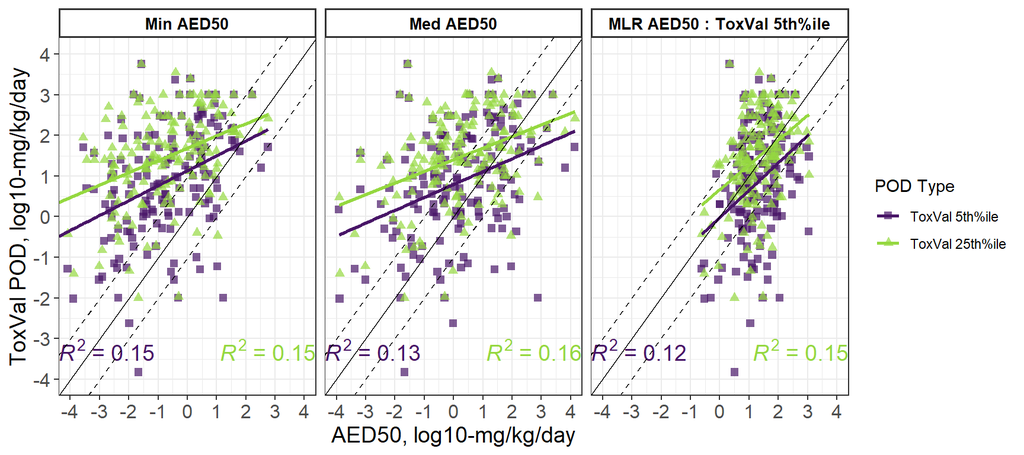

```r
# new facet labels
model.labels <- c('Min AED50',
                  'Med AED50',
                  'MLR AED50 : ToxVal 5th%ile')
names(model.labels) <- c('min.aed50','med.aed50','mlr.pred25')


aed.model.lm <- ggplot(data=asnm.tier1.pred3.long2[pod.type %in% c('p5.toxval.numeric',
                                                                   'p25.toxval.numeric')
                                                   & model.type %in% c('min.aed50',
                                                                       'med.aed50',
                                                                       'mlr.pred25')],
                 aes(x=model.value,
                     y=pod,
                     color=pod.type, shape=pod.type))+
  geom_point(aes(x=model.value,
                 y=pod,
                 color=pod.type, shape=pod.type), alpha=0.7, size=2)+
  scale_color_manual(name='POD Type',
                     values=c('#481567FF','#95D840FF'),
                     labels=c('ToxVal 5th%ile', 'ToxVal 25th%ile'),
                     breaks = c('p5.toxval.numeric',
                                'p25.toxval.numeric'))+
  scale_shape_manual(name='POD Type',
                     values=c(15,17),
                     labels=c('ToxVal 5th%ile', 'ToxVal 25th%ile'),
                     breaks = c('p5.toxval.numeric',
                                'p25.toxval.numeric'))+
  scale_x_continuous(breaks=seq(-7, 5, 1))+
  scale_y_continuous(breaks=seq(-7, 5, 1))+
  coord_cartesian(xlim=c(-4,4), ylim=c(-4,4))+
  theme_bw()+
  geom_smooth(aes(group=pod.type), method='lm',se=FALSE,formula=y~x)+
  stat_poly_eq(
               formula=y ~x,
               #eq.with.lhs = "y~`=`~",
               aes(label=paste0("atop(",..rr.label..,")")),
               parse=TRUE,
               #label.x=c(rep('right',3), 'left'),
               label.y=c(-2,-4),
               label.x=c(-3,1),
               size=5, face='bold')+
  geom_abline(slope=1, intercept=0) +
  geom_abline(slope=1, intercept=1, linetype="dashed") +
  geom_abline(slope=1, intercept=-1, linetype="dashed") +
  xlab('AED50, log10-mg/kg/day')+
  ylab('ToxVal POD, log10-mg/kg/day')+
   theme(axis.text = element_text(size=12),
        axis.title = element_text(size=14))+
  facet_wrap(~model.type, scales='fixed', labeller = labeller(model.type=model.labels))+
  theme(strip.background = element_rect(fill='white',size=1),
        strip.text = element_text(size=10, color='black',face='bold'))

aed.model.lm
```

For R1, adding targeted and broad min and med.

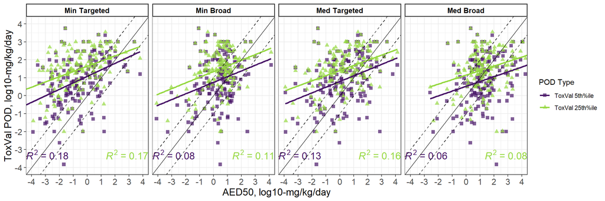

```r
# new facet labels
model.labels <- c('Min Broad',
                  'Min Targeted',
                  'Med Broad',
                  'Med Targeted')
names(model.labels) <- c('min.broad.aed50','min.targeted.aed50','med.broad.aed50','med.targeted.aed50')

# main plot
aed.model.broadvtarget <- ggplot(data=asnm.tier1.pred3.long2[pod.type %in% c('p5.toxval.numeric',
                                                                   'p25.toxval.numeric')
                                                   & model.type %in% c('min.broad.aed50','min.targeted.aed50',
                                                                       'med.broad.aed50', 'med.targeted.aed50')],
                 aes(x=model.value,
                     y=pod,
                     color=pod.type, shape=pod.type))+
  geom_point(aes(x=model.value,
                 y=pod,
                 color=pod.type, shape=pod.type), alpha=0.7, size=2)+
  scale_color_manual(name='POD Type',
                     values=c('#481567FF','#95D840FF'),
                     labels=c('ToxVal 5th%ile', 'ToxVal 25th%ile'),
                     breaks = c('p5.toxval.numeric',
                                'p25.toxval.numeric'))+
  scale_shape_manual(name='POD Type',
                     values=c(15,17),
                     labels=c('ToxVal 5th%ile', 'ToxVal 25th%ile'),
                     breaks = c('p5.toxval.numeric',
                                'p25.toxval.numeric'))+
  scale_x_continuous(breaks=seq(-7, 5, 1))+
  scale_y_continuous(breaks=seq(-7, 5, 1))+
  coord_cartesian(xlim=c(-4,4), ylim=c(-4,4))+
  theme_bw()+
  geom_smooth(aes(group=pod.type), method='lm',se=FALSE,formula=y~x)+
  stat_poly_eq(
               formula=y ~x,
               #eq.with.lhs = "y~`=`~",
               aes(label=paste0("atop(",..rr.label..,")")),
               parse=TRUE,
               #label.x=c(rep('right',3), 'left'),
               label.y=c(-2,-4),
               label.x=c(-3,1),
               size=5, face='bold')+
  geom_abline(slope=1, intercept=0) +
  geom_abline(slope=1, intercept=1, linetype="dashed") +
  geom_abline(slope=1, intercept=-1, linetype="dashed") +
  xlab('AED50, log10-mg/kg/day')+
  ylab('ToxVal POD, log10-mg/kg/day')+
   theme(axis.text = element_text(size=12),
        axis.title = element_text(size=14))+
  facet_wrap(~model.type, scales='fixed', labeller = labeller(model.type=model.labels), nrow=1, ncol=4)+
  theme(strip.background = element_rect(fill='white',size=1),
        strip.text = element_text(size=10, color='black',face='bold'))

aed.model.broadvtarget
```

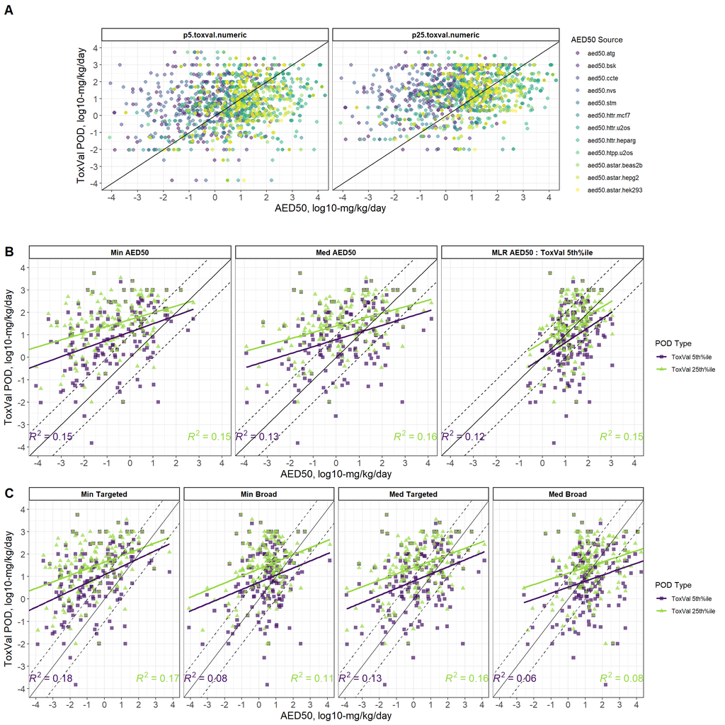

```r
fig.PODNAM <- plot_grid(aed.asnm.lm,
                        aed.model.lm,
                        aed.model.broadvtarget,
                        labels=c("A","B", "C"),
                        label_size=18,
                        nrow=3,
                        #align='v',
                        #rel_widths = c(1,2),
                        #rel_heights = c(1,1),
                        scale=c(0.8,1,1))

fig.PODNAM
```

```r
file.dir <- paste('output/', sep='')
file.name <- paste('/Fig_PODNAM_derivation_', Sys.Date(), '.tiff', sep='')
file.path <- paste(file.dir, file.name, sep='')
dir.create(path=file.dir, showWarnings = FALSE, recursive = TRUE)
tiff(file.path, width=10, height=14, units='in', res=450)
plot_grid(aed.asnm.lm,
                        aed.model.lm,
                        aed.model.broadvtarget,
                        labels=c("A","B", "C"),
                        label_size=18,
                        nrow=3,
                        align='v',
                        #rel_widths = c(1,2),
                        #rel_heights = c(1,1),
                        scale=c(0.8,1,1))
dev.off()
```

# 7 Putting together the data sheet

Add summary columns to dataframe

```r
colnames(asnm.tier1.all)
```

```
##  [1] "dsstox_substance_id"
##  [2] "aed50.3compss.5pacc"
##  [3] "aed50.3compss.atg"
##  [4] "aed50.3compss.bsk"
##  [5] "aed50.3compss.ccte"
##  [6] "aed50.3compss.nvs"
##  [7] "aed50.3compss.stm"
##  [8] "aed50.3compss.httr.mcf7.sigbmd"
##  [9] "aed50.3compss.httr.u2os.sigbmd"
## [10] "aed50.3compss.httr.heparg.sigbmd"
## [11] "aed50.3compss.htpp.u2os"
## [12] "aed50.3compss.astar.beas2b"
## [13] "aed50.3compss.astar.hepg2"
## [14] "aed50.3compss.astar.hek293"
## [15] "aed50.pbtk.5pacc"
```

[output cut: 52 more lines]

```r
# add in the MLR Results

asnm.tier1.all[,mlr.toxval5.aed50 := sum((coeff.tbl25[var_name=="aed50.atg"]$mlr_coeff)*aed50.atg
                + (coeff.tbl25[var_name=="aed50.bsk"]$mlr_coeff)*aed50.bsk
                 + (coeff.tbl25[var_name=="aed50.ccte"]$mlr_coeff)*aed50.ccte
                 + (coeff.tbl25[var_name=="aed50.nvs"]$mlr_coeff)*aed50.nvs
                 + (coeff.tbl25[var_name=="aed50.stm"]$mlr_coeff)*aed50.stm
                 + (coeff.tbl25[var_name=="aed50.httr.mcf7"]$mlr_coeff)*aed50.httr.mcf7
                 + (coeff.tbl25[var_name=="aed50.httr.u2os"]$mlr_coeff)*aed50.httr.u2os
                 + (coeff.tbl25[var_name=="aed50.httr.heparg"]$mlr_coeff)*aed50.httr.heparg
                 + (coeff.tbl25[var_name=="aed50.htpp.u2os"]$mlr_coeff)*aed50.htpp.u2os
                 + (coeff.tbl25[var_name=="aed50.astar.beas2b"]$mlr_coeff)*aed50.astar.beas2b
                 + (coeff.tbl25[var_name=="aed50.astar.hepg2"]$mlr_coeff)*aed50.astar.hepg2
                 + (coeff.tbl25[var_name=="aed50.astar.hek293"]$mlr_coeff)*aed50.astar.hek293, na.rm=TRUE), by=c('dsstox_substance_id')]

asnm.tier1.all[,mlr.toxval25.aed50 := sum((coeff.tbl25[var_name=="aed50.atg"]$mlr_coeff)*aed50.atg
                + (coeff.tbl25[var_name=="aed50.bsk"]$mlr_coeff)*aed50.bsk
                 + (coeff.tbl25[var_name=="aed50.ccte"]$mlr_coeff)*aed50.ccte
                 + (coeff.tbl25[var_name=="aed50.nvs"]$mlr_coeff)*aed50.nvs
                 + (coeff.tbl25[var_name=="aed50.stm"]$mlr_coeff)*aed50.stm
                 + (coeff.tbl25[var_name=="aed50.httr.mcf7"]$mlr_coeff)*aed50.httr.mcf7
                 + (coeff.tbl25[var_name=="aed50.httr.u2os"]$mlr_coeff)*aed50.httr.u2os
                 + (coeff.tbl25[var_name=="aed50.httr.heparg"]$mlr_coeff)*aed50.httr.heparg
                 + (coeff.tbl25[var_name=="aed50.htpp.u2os"]$mlr_coeff)*aed50.htpp.u2os
                 + (coeff.tbl25[var_name=="aed50.astar.beas2b"]$mlr_coeff)*aed50.astar.beas2b
                 + (coeff.tbl25[var_name=="aed50.astar.hepg2"]$mlr_coeff)*aed50.astar.hepg2
                 + (coeff.tbl25[var_name=="aed50.astar.hek293"]$mlr_coeff)*aed50.astar.hek293, na.rm=TRUE), by=c('dsstox_substance_id')]
```

```r
# take median (no ccte MEA)
asnm.tier1.all <- asnm.tier1.all %>% rowwise() %>% mutate(med.aed50=median(c(aed50.atg,
aed50.bsk, aed50.nvs, aed50.stm, aed50.httr.mcf7,
aed50.httr.u2os, aed50.httr.heparg, aed50.htpp.u2os, aed50.astar.beas2b,
aed50.astar.hepg2, aed50.astar.hek293),na.rm=TRUE)) %>% data.table()

# take minimum, no ccte (no MEA)
asnm.tier1.all <- asnm.tier1.all %>% rowwise() %>% mutate(min.aed50=min(c(aed50.atg,
aed50.bsk, aed50.nvs, aed50.stm, aed50.httr.mcf7,
aed50.httr.u2os, aed50.httr.heparg, aed50.htpp.u2os, aed50.astar.beas2b,
aed50.astar.hepg2, aed50.astar.hek293), na.rm=TRUE)) %>% data.table()

# median of targeted NAMs (no CCTE - no MEA)
asnm.tier1.all <- asnm.tier1.all %>% rowwise() %>% mutate(med.targeted.aed50=median(c(aed50.atg,
aed50.bsk, aed50.nvs, aed50.stm),na.rm=TRUE)) %>% data.table()

# minimum of targeted NAMs
asnm.tier1.all <- asnm.tier1.all %>% rowwise() %>% mutate(min.targeted.aed50=min(c(aed50.atg,
aed50.bsk, aed50.nvs, aed50.stm),na.rm=TRUE)) %>% data.table()

# median of broad profiling
asnm.tier1.all <- asnm.tier1.all %>% rowwise() %>% mutate(med.broad.aed50=median(c(aed50.httr.mcf7,
aed50.httr.u2os, aed50.httr.heparg, aed50.htpp.u2os),na.rm=TRUE)) %>% data.table()

# minimum of broad profiling
asnm.tier1.all<- asnm.tier1.all %>% rowwise() %>% mutate(min.broad.aed50=min(c(aed50.httr.mcf7,
aed50.httr.u2os, aed50.httr.heparg),na.rm=TRUE)) %>% data.table()
```

```r
# for input to hazard flag and BER calculation

save(asnm.tier1.pred3, asnm.tier1.all, file= './output/aed_tbl_Nov2024.RData')
```

```r
load(file= './output/aed_tbl_Nov2024.RData')
```

# 8 Load In vivo Data

## 8.1 ECHA POD Information

```r
echa.repdose <- read.xlsx('./source/in_vivo/draft_apcra_pro_selection_tbl_9_Feb_2023_InVivo_screening.xlsx', sheet=3, colNames = TRUE) %>% data.table()
```

```r
echa.systemic <- as.data.table(echa.repdose)
header.true <- function(df) {
  names(df) <- as.character(unlist(df[1,]))
  df[-1,]
}
echa.systemic <- header.true(echa.systemic)

echa.systemic <- echa.systemic[,c('chnm','dsstox_substance_id',
                                  'data poor - no repeat dose toxicity data on the substance / no plans',
                                  'Katie_quant_dose_lowest_LOAEL_mkd',
                                  'Katie_quant_dose_lowest_NOAEL_mkd',
                                  'Katie_422_syst_LOAEL_mkd',                                                         'Katie_422_syst_NOAEL_mkd')]

colnames(echa.systemic)
```

```
## [1] "chnm"
## [2] "dsstox_substance_id"
## [3] "data poor - no repeat dose toxicity data on the substance / no plans"
## [4] "Katie_quant_dose_lowest_LOAEL_mkd"
## [5] "Katie_quant_dose_lowest_NOAEL_mkd"
## [6] "Katie_422_syst_LOAEL_mkd"
## [7] "Katie_422_syst_NOAEL_mkd"
```

```r
setnames(echa.systemic, names(echa.systemic), c('chnm','dsstox_substance_id','data_poor_notes',
                                                'OECD_407_408_LOAEL_mkd','OECD_407_408_NOAEL_mkd',
                                                'OECD_422syst_LOAEL_mkd','OECD_422syst_NOAEL_mkd'))
```

```r
echa.systemic[grep('no', data_poor_notes), data_poor_binary := 0]
echa.systemic[grep('data generation', data_poor_notes), data_poor_binary := 0]
# what does it mean if there's no note? Data poor?
echa.systemic[is.na(data_poor_notes), data_poor_binary := 1]
echa.systemic[grep('yes',data_poor_notes), data_poor_binary := 1]
head(echa.systemic)
```

| chnm | dsstox_substance_id | data_poor_notes | OECD_407_408_LOAEL_mkd | OECD_407_408_NOAEL_mkd | OECD_422syst_LOAEL_mkd | OECD_422syst_NOAEL_mkd | data_poor_binary |
| --- | --- | --- | --- | --- | --- | --- | --- |
| 2-Chloro-1,4-diaminobenzene sulfate | DTXSID0020284 | yes (not registered) | NA | NA | NA | NA | 1 |
| 2,4-Dinitrophenol | DTXSID0020523 | NA | NA | NA | NA | NA | 1 |
| Sulfasalazine | DTXSID0021256 | NA | NA | NA | NA | NA | 1 |
| Tetramethylthiuram monosulfide | DTXSID0021333 | no | NA | NA | 5 | NA | 0 |
| Thiabendazole | DTXSID0021337 | NA | NA | NA | NA | NA | 1 |
| Diphenolic acid | DTXSID0022436 | yes (not registered) | NA | NA | NA | NA | 1 |

```r
change_cols <- c('OECD_407_408_LOAEL_mkd','OECD_407_408_NOAEL_mkd',
                                                'OECD_422syst_LOAEL_mkd','OECD_422syst_NOAEL_mkd')
echa.systemic[, (change_cols) := lapply(.SD, as.numeric), .SDcols = change_cols]
echa.systemic[, ECHA_min_systemic_POD_mkd := min(OECD_407_408_LOAEL_mkd,OECD_407_408_NOAEL_mkd,
                                                OECD_422syst_LOAEL_mkd,OECD_422syst_NOAEL_mkd, na.rm=TRUE), by=chnm]
echa.systemic[, ECHA_min_systemic_POD_mkd := lapply(.SD, as.numeric), .SDcols = 'ECHA_min_systemic_POD_mkd']

for (j in 1:ncol(echa.systemic)) set(echa.systemic, which(is.infinite(echa.systemic[[j]])), j, NA)
```

```r
nrow(echa.systemic[!is.na(ECHA_min_systemic_POD_mkd)])
```

```
## [1] 43
```

## 8.2 ToxVal PODs

- Load ToxVal
- See how many we have for each type of ToxVal and ECHA data
- show performance in multiple panels

```r
load('./source/in_vivo/apcra_pro_toxval_v9_4_PODs.RData')
```

```r
toxval.all <- merge.data.table(toxval.apcra.summary,
                               toxval.apcra.summary.subchronic,
                               all.x=TRUE, all.y = TRUE, by=c('dtxsid'))

toxval.all <- merge.data.table(toxval.all,
                               apcra.list[,c('DTXSID', 'CASRN', 'preferred_name')],
                               all.x=TRUE,
                               all.y=TRUE,
                               by.x=c('dtxsid'),
                               by.y=c('DTXSID'))

setnames(toxval.all, c('dtxsid'), c('dsstox_substance_id'))

invivo.all <- merge.data.table(toxval.all,echa.systemic,
                               all.x=TRUE,
                               all.y=TRUE,
                               by =c('dsstox_substance_id'))

invivo.all <- invivo.all[!is.na(dsstox_substance_id)]
```

```r
#invivo.all[is.na(CASRN)]
invivo.all[,c('casrn.x','name.x','chnm','name.y','casrn.y') := NULL]
setcolorder(invivo.all, c(1,29:30,2:28,31:37))
colnames(invivo.all)
```

```
##  [1] "dsstox_substance_id"       "CASRN"
##  [3] "preferred_name"            "min.toxval.numeric"
##  [5] "p5.toxval.numeric"         "p10.toxval.numeric"
##  [7] "p15.toxval.numeric"        "p20.toxval.numeric"
##  [9] "p25.toxval.numeric"        "p30.toxval.numeric"
## [11] "max.toxval.numeric"        "median.toxval.numeric"
## [13] "mean.toxval.numeric"       "stdev.toxval.numeric"
## [15] "number.toxval.numeric"     "apcra.ret.5p.POD"
## [17] "diff"                      "label"
## [19] "min.toxval.numeric.sub"    "p5.toxval.numeric.sub"
## [21] "p10.toxval.numeric.sub"    "p15.toxval.numeric.sub"
## [23] "p20.toxval.numeric.sub"    "p25.toxval.numeric.sub"
## [25] "p30.toxval.numeric.sub"    "max.toxval.numeric.sub"
## [27] "median.toxval.numeric.sub" "mean.toxval.numeric.sub"
## [29] "stdev.toxval.numeric.sub"  "number.toxval.numeric.sub"
## [31] "data_poor_notes"           "OECD_407_408_LOAEL_mkd"
## [33] "OECD_407_408_NOAEL_mkd"    "OECD_422syst_LOAEL_mkd"
## [35] "OECD_422syst_NOAEL_mkd"    "data_poor_binary"
## [37] "ECHA_min_systemic_POD_mkd"
```

```r
kable(invivo.all,
           filter='top',
          options=list(pagelength=25, autoWidth=FALSE,  scrollX=TRUE, initComplete = JS(
    "function(settings, json) {",
    "$('body').css({'font-family': 'Calibri'});",
    "}"
  )))
```

| dsstox_substance_id | CASRN | preferred_name | min.toxval.numeric | p5.toxval.numeric | p10.toxval.numeric | p15.toxval.numeric | p20.toxval.numeric | p25.toxval.numeric | p30.toxval.numeric | max.toxval.numeric | median.toxval.numeric | mean.toxval.numeric | stdev.toxval.numeric | number.toxval.numeric | apcra.ret.5p.POD | diff | label | min.toxval.numeric.sub | p5.toxval.numeric.sub | p10.toxval.numeric.sub | p15.toxval.numeric.sub | p20.toxval.numeric.sub | p25.toxval.numeric.sub | p30.toxval.numeric.sub | max.toxval.numeric.sub | median.toxval.numeric.sub | mean.toxval.numeric.sub | stdev.toxval.numeric.sub | number.toxval.numeric.sub | … |
| --- | --- | --- | --- | --- | --- | --- | --- | --- | --- | --- | --- | --- | --- | --- | --- | --- | --- | --- | --- | --- | --- | --- | --- | --- | --- | --- | --- | --- | --- | --- |
| DTXSID0020284 | 61702-44-1 | 2-Chloro-1,4-diaminobenzene sulfate | NA | NA | NA | NA | NA | NA | NA | NA | NA | NA | NA | NA | NA | NA | NA | NA | NA | NA | NA | NA | NA | NA | NA | NA | NA | NA | NA | … |
| DTXSID0020523 | 51-28-5 | 2,4-Dinitrophenol | 7.00000e-02 | 0.0700000 | 0.0700000 | 0.2850000 | 0.5000000 | 1.2500000 | 2.0000000 | 3.00000e+01 | 2.0000000 | 8.412727e+00 | 1.204637e+01 | 11 | 2.0000 | -1.4559320 | 2,4-Dinitrophenol | 7.000e-02 | 0.24200 | 0.41400 | 0.80000 | 1.40000 | 2.00000 | 2.00000 | 30.00 | 2.95 | 1.005222e+01 | 1.282690e+01 | 9 | … |
| DTXSID0021256 | 599-79-1 | Sulfasalazine | 8.40000e+01 | 84.0000000 | 84.0000000 | 168.0000000 | 168.0000000 | 168.8000000 | 337.5000000 | 2.70000e+03 | 506.2500000 | 8.776181e+02 | 9.509670e+02 | 72 | 126.0000 | -0.1760913 |  | 8.400e+01 | 84.00000 | 84.00000 | 113.68000 | 168.80000 | 168.80000 | 168.80000 | 2700.00 | 337.50 | 7.171333e+02 | 8.549922e+02 | 30 | … |
| DTXSID0021333 | 97-74-5 | Tetramethylthiuram monosulfide | 1.00000e-01 | 0.4300000 | 0.7600000 | 1.0900000 | 4.9600000 | 10.6000000 | 16.2400000 | 1.00000e+02 | 26.0000000 | 2.847143e+01 | 3.355367e+01 | 7 | NA | NA |  | 2.000e+01 | 20.90000 | 21.80000 | 22.70000 | 23.60000 | 24.50000 | 25.40000 | 26.00 | 26.00 | 2.450000e+01 | 3.000000e+00 | 4 | … |
| DTXSID0021337 | 148-79-8 | Thiabendazole | 6.50000e-03 | 9.5200000 | 10.0000000 | 10.0000000 | 25.0000000 | 30.0000000 | 30.1000000 | 7.69500e+02 | 90.0000000 | 1.379467e+02 | 1.692411e+02 | 165 | 9.4000 | 0.0055091 |  | 6.500e-03 | 9.40000 | 25.00000 | 25.00000 | 25.00000 | 35.00000 | 37.00000 | 500.00 | 100.00 | 1.472608e+02 | 1.379838e+02 | 56 | … |
| DTXSID0022436 | 126-00-1 | Diphenolic acid | NA | NA | NA | NA | NA | NA | NA | NA | NA | NA | NA | NA | NA | NA | NA | NA | NA | NA | NA | NA | NA | NA | NA | NA | NA | NA | NA | … |
| DTXSID0023745 | 58-86-6 | D-Xylose | 2.50000e+03 | 2500.0000000 | 2500.0000000 | 2500.0000000 | 2500.0000000 | 2500.0000000 | 2500.0000000 | 2.00000e+04 | 3750.0000000 | 8.750000e+03 | 8.128433e+03 | 8 | NA | NA |  | 2.500e+03 | 2500.00000 | 2500.00000 | 2500.00000 | 2500.00000 | 2500.00000 | 2500.00000 | 15000.00 | 3750.00 | 6.250000e+03 | 5.951190e+03 | 4 | … |
| DTXSID0023901 | 25057-89-0 | Bentazone | 1.40000e-02 | 3.5224150 | 9.0000000 | 12.3041000 | 15.0000000 | 15.0000000 | 28.9000000 | 2.58300e+02 | 62.0000000 | 1.037235e+02 | 9.782050e+01 | 111 | 3.2000 | 0.0416905 |  | 2.500e+01 | 25.30000 | 26.02000 | 28.90000 | 41.34000 | 68.90000 | 77.80000 | 258.30 | 243.30 | 1.647435e+02 | 1.027087e+02 | 23 | … |
| DTXSID0023951 | 5234-68-4 | Carboxin | 8.00000e-01 | 1.0000000 | 5.5000000 | 9.0000000 | 10.0000000 | 10.0000000 | 10.0000000 | 9.12000e+02 | 17.7000000 | 8.765817e+01 | 1.896204e+02 | 131 | 0.8000 | 0.0969100 |  | 5.500e+00 | 5.50000 | 6.83000 | 9.00000 | 9.60000 | 10.00000 | 10.00000 | 100.00 | 14.10 | 2.884118e+01 | 3.158167e+01 | 34 | … |
| DTXSID0024216 | 1929-82-4 | Nitrapyrin | 3.00000e+00 | 5.0000000 | 5.0000000 | 10.0000000 | 15.0000000 | 20.0000000 | 20.0000000 | 8.00000e+02 | 45.0000000 | 8.211558e+01 | 1.191545e+02 | 199 | 5.0000 | 0.0000000 |  | 5.000e+00 | 18.00000 | 30.00000 | 36.00000 | 45.00000 | 45.00000 | 50.00000 | 800.00 | 150.00 | 1.972973e+02 | 2.080918e+02 | 37 | … |
| DTXSID0032493 | 55219-65-3 | Triadimenol | 3.40000e+00 | 5.0000000 | 5.0000000 | 7.1875000 | 15.0000000 | 25.0000000 | 25.0000000 | 8.68000e+02 | 44.2000000 | 1.272713e+02 | 2.015161e+02 | 126 | 6.2500 | -0.0969100 |  | 3.400e+00 | 7.50000 | 8.98000 | 30.00000 | 33.84000 | 39.60000 | 44.20000 | 717.00 | 120.00 | 1.869729e+02 | 2.296396e+02 | 48 | … |
| DTXSID0032520 | 131860-33-8 | Azoxystrobin | 3.00000e+00 | 6.4000000 | 18.2000000 | 22.3000000 | 25.0000000 | 25.0000000 | 32.3000000 | 8.00000e+02 | 117.1000000 | 1.607482e+02 | 1.876090e+02 | 141 | 18.2000 | -0.4538914 |  | 1.000e+01 | 10.00000 | 20.40000 | 20.97000 | 22.40000 | 22.40000 | 24.74000 | 448.60 | 211.00 | 1.740824e+02 | 1.585165e+02 | 34 | … |
| DTXSID0032601 | 94361-06-5 | Cyproconazole | 1.00000e+00 | 1.4000000 | 1.6700000 | 2.0000000 | 2.5000000 | 3.2000000 | 5.7000000 | 1.39400e+02 | 12.6000000 | 2.637000e+01 | 3.259356e+01 | 223 | 2.0000 | -0.1549020 |  | 1.000e+00 | 1.49500 | 1.59000 | 1.98500 | 3.06000 | 4.00000 | 5.90000 | 139.40 | 25.01 | 3.841390e+01 | 4.153119e+01 | 100 | … |
| DTXSID0032655 | 131983-72-7 | Triticonazole | 2.00000e-01 | 0.2500000 | 2.2300000 | 17.4000000 | 20.1000000 | 25.0000000 | 26.3200000 | 2.36880e+03 | 123.6506500 | 2.802815e+02 | 5.058169e+02 | 152 | 19.8000 | -1.8987252 | Triticonazole | 2.000e+00 | 2.01000 | 2.20000 | 2.20000 | 5.72000 | 19.80000 | 19.80000 | 2368.80 | 569.65 | 9.070773e+02 | 1.010209e+03 | 22 | … |
| DTXSID0039223 | 116-06-3 | Aldicarb | 1.20000e-04 | 0.0001500 | 0.0001500 | 0.0001500 | 0.0005000 | 0.0100000 | 0.0600000 | 1.50000e+02 | 0.4000000 | 3.507981e+00 | 1.962947e+01 | 125 | 0.0100 | -1.8239087 | Aldicarb | 1.500e-04 | 0.00015 | 0.00015 | 0.00015 | 0.00015 | 0.00015 | 0.00015 | 150.00 | 0.30 | 7.838810e+00 | 2.985641e+01 | 29 | … |
| DTXSID0040127 | 141-86-6 | 2,6-Diaminopyridine | NA | NA | NA | NA | NA | NA | NA | NA | NA | NA | NA | NA | NA | NA | NA | NA | NA | NA | NA | NA | NA | NA | NA | NA | NA | NA | NA | … |
| DTXSID0040707 | 33228-44-3 | 4-Pentylaniline | NA | NA | NA | NA | NA | NA | NA | NA | NA | NA | NA | NA | NA | NA | NA | NA | NA | NA | NA | NA | NA | NA | NA | NA | NA | NA | NA | … |
| DTXSID0041270 | 58430-94-7 | 3,5,5-Trimethylhexyl acetate | 4.00000e+01 | 40.0000000 | 40.0000000 | 40.0000000 | 48.0000000 | 60.0000000 | 72.0000000 | 4.00000e+02 | 250.0000000 | 2.085714e+02 | 1.581591e+02 | 7 | NA | NA |  | 4.000e+01 | 40.00000 | 40.00000 | 40.00000 | 40.00000 | 40.00000 | 48.00000 | 400.00 | 80.00 | 1.920000e+02 | 1.905781e+02 | 5 | … |
| DTXSID0044494 | 102-20-5 | 2-Phenylethyl phenylacetate | 4.30000e+00 | 17.8450000 | 31.3900000 | 43.3500000 | 45.8000000 | 48.2500000 | 65.0000000 | 1.00000e+03 | 290.0000000 | 3.346625e+02 | 3.365318e+02 | 8 | NA | NA |  | 2.000e+02 | 230.00000 | 260.00000 | 290.00000 | 320.00000 | 350.00000 | 380.00000 | 1000.00 | 500.00 | 5.666667e+02 | 4.041452e+02 | 3 | … |
| DTXSID0044608 | 17865-07-5 | Propylsilanetriyl triacetate | 1.00000e-02 | 0.0100000 | 0.0420000 | 0.0500000 | 1.8200000 | 3.0000000 | 10.2000000 | 3.60000e+03 | 1600.0000000 | 1.211954e+03 | 1.222762e+03 | 19 | NA | NA |  | 1.000e-02 | 0.01000 | 0.01000 | 0.01000 | 0.01000 | 0.01000 | 4.20800 | 3600.00 | 21.00 | 1.444204e+03 | 1.967982e+03 | 5 | … |
| DTXSID0044818 | 2/8/3913 | 2-Butyloctan-1-ol | 1.00000e+03 | 1000.0000000 | 1000.0000000 | 1000.0000000 | 1000.0000000 | 1000.0000000 | 1000.0000000 | 2.00000e+03 | 1000.0000000 | 1.285714e+03 | 4.879500e+02 | 7 | NA | NA |  | 1.000e+03 | 1000.00000 | 1000.00000 | 1000.00000 | 1000.00000 | 1000.00000 | 1000.00000 | 1000.00 | 1000.00 | 1.000000e+03 | NA | 1 | … |
| DTXSID0044997 | 88-27-7 | 2,6-Di-tert-butyl-4-[(dimethylamino)methyl]phenol | 2.50000e+01 | 25.0000000 | 30.0000000 | 45.0000000 | 50.0000000 | 50.0000000 | 50.0000000 | 1.50000e+02 | 50.0000000 | 8.361538e+01 | 5.028633e+01 | 13 | NA | NA |  | 2.500e+01 | 25.00000 | 25.00000 | 37.50000 | 50.00000 | 50.00000 | 50.00000 | 150.00 | 50.00 | 8.181818e+01 | 5.487589e+01 | 11 | … |
| DTXSID0047113 | 6790-58-5 | (-)-Ambroxide | 8.00000e+02 | 810.0000000 | 820.0000000 | 830.0000000 | 840.0000000 | 850.0000000 | 860.0000000 | 1.00000e+03 | 900.0000000 | 9.000000e+02 | 1.414214e+02 | 2 | NA | NA |  | 8.000e+02 | 810.00000 | 820.00000 | 830.00000 | 840.00000 | 850.00000 | 860.00000 | 1000.00 | 900.00 | 9.000000e+02 | 1.414214e+02 | 2 | … |
| DTXSID0048505 | NOCAS_48505 | PharmaGSID_48505 | NA | NA | NA | NA | NA | NA | NA | NA | NA | NA | NA | NA | NA | NA | NA | NA | NA | NA | NA | NA | NA | NA | NA | NA | NA | NA | NA | … |
| DTXSID1020142 | 91-76-9 | 6-Phenyl-1,3,5-triazine-2,4-diamine | 1.90000e+01 | 19.0000000 | 19.2000000 | 19.8000000 | 20.0000000 | 20.0000000 | 20.0000000 | 6.00000e+02 | 75.0000000 | 2.129231e+02 | 2.699075e+02 | 13 | NA | NA |  | 1.900e+01 | 19.00000 | 19.00000 | 19.00000 | 19.00000 | 19.00000 | 19.00000 | 20.00 | 19.50 | 1.950000e+01 | 5.773503e-01 | 4 | … |
| DTXSID1020560 | 115-29-7 | Endosulfan | 1.50000e-01 | 0.2985000 | 0.5000000 | 0.6000000 | 0.7500000 | 0.9000000 | 1.2300000 | 6.25000e+01 | 2.6000000 | 5.367775e+00 | 8.288139e+00 | 240 | 0.3750 | -0.0990869 |  | 2.700e-01 | 0.50000 | 0.53300 | 1.00000 | 1.50000 | 1.50000 | 2.48900 | 62.50 | 4.00 | 6.755048e+00 | 8.372590e+00 | 104 | … |
| DTXSID1021166 | 51-03-6 | Piperonyl butoxide | 1.50000e+00 | 15.0000000 | 25.0000000 | 30.0000000 | 50.0000000 | 89.0000000 | 100.0000000 | 4.00000e+03 | 250.0000000 | 3.921659e+02 | 5.015282e+02 | 283 | 2.9000 | 0.7136933 |  | 1.000e+01 | 15.00000 | 25.00000 | 43.00000 | 60.00000 | 100.00000 | 100.00000 | 1850.00 | 300.00 | 3.744967e+02 | 4.199627e+02 | 72 | … |
| DTXSID1021956 | 117-84-0 | Di-n-octyl phthalate | 3.68000e+01 | 36.8000000 | 36.8000000 | 36.8000000 | 38.4000000 | 39.7000000 | 40.0000000 | 9.78000e+03 | 1000.0000000 | 3.828300e+03 | 4.344958e+03 | 20 | 36.8000 | 0.0000000 |  | 3.680e+01 | 36.80000 | 36.80000 | 36.80000 | 37.60000 | 38.80000 | 39.52000 | 9780.00 | 1000.00 | 2.648400e+03 | 4.088399e+03 | 13 | … |
| DTXSID1023990 | 21725-46-2 | Cyanazine | 5.00000e-03 | 0.0562500 | 0.0750000 | 0.1312500 | 0.6800000 | 1.0000000 | 1.0000000 | 2.25000e+02 | 3.2000000 | 2.247887e+01 | 5.193749e+01 | 106 | 0.0750 | -0.1249387 |  | 5.000e-03 | 0.00500 | 0.05000 | 0.07500 | 0.07500 | 0.07500 | 0.07500 | 225.00 | 3.75 | 3.607109e+01 | 7.283763e+01 | 46 | … |
| DTXSID1024091 | 759-94-4 | EPTC | 1.00000e+00 | 2.1250000 | 2.5000000 | 3.0000000 | 5.0000000 | 10.0000000 | 10.0000000 | 3.00000e+02 | 40.0000000 | 6.033219e+01 | 8.309837e+01 | 146 | 1.0000 | 0.3273589 |  | 3.000e+00 | 3.00000 | 3.00000 | 3.00000 | 3.00000 | 3.00000 | 15.00000 | 120.00 | 15.00 | 4.445161e+01 | 4.434775e+01 | 31 | … |

[output cut: 171 more lines]

Make all units log10-mg/kg/day

```r
# ECHA data
invivo.all[, log.ECHA_min_systemic_POD_mkd := log10(ECHA_min_systemic_POD_mkd)]

# Toxval
invivo.all[, p5.toxval.numeric := log10(p5.toxval.numeric)]
invivo.all[, p10.toxval.numeric := log10(p10.toxval.numeric)]
invivo.all[, p15.toxval.numeric := log10(p15.toxval.numeric)]
invivo.all[, p20.toxval.numeric := log10(p20.toxval.numeric)]
invivo.all[, p25.toxval.numeric := log10(p25.toxval.numeric)]
invivo.all[, p30.toxval.numeric := log10(p30.toxval.numeric)]

# ToxVal - subchronic only
invivo.all[, p5.toxval.numeric.sub := log10(p5.toxval.numeric.sub)]
invivo.all[, p10.toxval.numeric.sub := log10(p10.toxval.numeric.sub)]
invivo.all[, p15.toxval.numeric.sub := log10(p15.toxval.numeric.sub)]
invivo.all[, p20.toxval.numeric.sub := log10(p20.toxval.numeric.sub)]
invivo.all[, p25.toxval.numeric.sub := log10(p25.toxval.numeric.sub)]
invivo.all[, p30.toxval.numeric.sub := log10(p30.toxval.numeric.sub)]
```

Make all log.repdose values that combine ECHA and ToxVal per logic

```r
# ToxVal
invivo.all[, log.repdose.any.5th := ifelse(is.na(log.ECHA_min_systemic_POD_mkd), p5.toxval.numeric, log.ECHA_min_systemic_POD_mkd)]
invivo.all[, log.repdose.any.10th := ifelse(is.na(log.ECHA_min_systemic_POD_mkd), p10.toxval.numeric, log.ECHA_min_systemic_POD_mkd)]
invivo.all[, log.repdose.any.15th := ifelse(is.na(log.ECHA_min_systemic_POD_mkd), p15.toxval.numeric, log.ECHA_min_systemic_POD_mkd)]
invivo.all[, log.repdose.any.20th := ifelse(is.na(log.ECHA_min_systemic_POD_mkd), p20.toxval.numeric, log.ECHA_min_systemic_POD_mkd)]
invivo.all[, log.repdose.any.25th := ifelse(is.na(log.ECHA_min_systemic_POD_mkd), p25.toxval.numeric, log.ECHA_min_systemic_POD_mkd)]
invivo.all[, log.repdose.any.30th := ifelse(is.na(log.ECHA_min_systemic_POD_mkd), p30.toxval.numeric, log.ECHA_min_systemic_POD_mkd)]

# ToxVal - subchronic only
invivo.all[, log.repdose.90d.5th := ifelse(is.na(log.ECHA_min_systemic_POD_mkd), p5.toxval.numeric.sub, log.ECHA_min_systemic_POD_mkd)]
invivo.all[, log.repdose.90d.10th := ifelse(is.na(log.ECHA_min_systemic_POD_mkd), p10.toxval.numeric.sub, log.ECHA_min_systemic_POD_mkd)]
invivo.all[, log.repdose.90d.15th := ifelse(is.na(log.ECHA_min_systemic_POD_mkd), p15.toxval.numeric.sub, log.ECHA_min_systemic_POD_mkd)]
invivo.all[, log.repdose.90d.20th := ifelse(is.na(log.ECHA_min_systemic_POD_mkd), p20.toxval.numeric.sub, log.ECHA_min_systemic_POD_mkd)]
invivo.all[, log.repdose.90d.25th := ifelse(is.na(log.ECHA_min_systemic_POD_mkd), p25.toxval.numeric.sub, log.ECHA_min_systemic_POD_mkd)]
invivo.all[, log.repdose.90d.30th := ifelse(is.na(log.ECHA_min_systemic_POD_mkd), p30.toxval.numeric.sub, log.ECHA_min_systemic_POD_mkd)]

nrow(invivo.all[!is.na(log.repdose.90d.5th)]) # 163 chemicals with 90d repeat dose POD
```

```
## [1] 163
```

```r
nrow(invivo.all[!is.na(log.repdose.any.25th)]) # 167 chemicals with any repeat dose POD
```

```
## [1] 167
```

# 9 Compare ECHA and ToxVal values

## 9.1 Compare in vivo PODs

```r
# make list of linear model comparisons
## Toxval 5p and 25 p to SUB only
iv.mod1 <- lm(p5.toxval.numeric ~ p5.toxval.numeric.sub,
            data= invivo.all)
iv.mod2 <- lm(p25.toxval.numeric ~ p25.toxval.numeric.sub,
            data= invivo.all)
# ECHA min systemic to Toxval
iv.mod3 <- lm(log.ECHA_min_systemic_POD_mkd ~ p5.toxval.numeric,
            data= invivo.all)
iv.mod4 <- lm(log.ECHA_min_systemic_POD_mkd ~ p25.toxval.numeric,
            data= invivo.all)

iv.mod1.rmse <- round(sqrt(mean(iv.mod1$residuals^2)),3)
iv.mod1.r2 <- round(summary(iv.mod1)$r.squared,3)

iv.mod2.rmse <- round(sqrt(mean(iv.mod2$residuals^2)),3)
iv.mod2.r2 <- round(summary(iv.mod2)$r.squared,3)

iv.mod3.rmse <- round(sqrt(mean(iv.mod3$residuals^2)),3)
iv.mod3.r2 <- round(summary(iv.mod3)$r.squared,3)

iv.mod4.rmse <- round(sqrt(mean(iv.mod4$residuals^2)),3)
iv.mod4.r2 <- round(summary(iv.mod4)$r.squared,3)

pod <- c('5th%ile SUB to 5th%ile',
         '25th%ile SUB to 25%ile',
         '5th%ile to Min ECHA',
         '25th%ile to Min ECHA')

pod.rmse <- c(iv.mod1.rmse,
              iv.mod2.rmse,
              iv.mod3.rmse,
              iv.mod4.rmse)

pod.r2 <- c(iv.mod1.r2,
            iv.mod2.r2,
            iv.mod3.r2,
            iv.mod4.r2)


summ.pod <- data.table(pod,
                   pod.rmse,
                   pod.r2)

setnames(summ.pod, c('pod','pod.rmse','pod.r2'), c('POD comparison','RMSE','R2'))
kable(summ.pod)
```

| POD comparison | RMSE | R2 |
| --- | --- | --- |
| 5th%ile SUB to 5th%ile | 0.484 | 0.874 |
| 25th%ile SUB to 25%ile | 0.506 | 0.792 |
| 5th%ile to Min ECHA | 0.470 | 0.457 |
| 25th%ile to Min ECHA | 0.420 | 0.566 |

```r
# make in vivo data long to plot
invivo.all.long <- melt.data.table(invivo.all,
                                         id.vars=c('dsstox_substance_id',
                                                   'p5.toxval.numeric',
                                                   'p25.toxval.numeric'),
                                         measure.vars=c('p5.toxval.numeric.sub',
                                                     'p25.toxval.numeric.sub',
                                                     'log.ECHA_min_systemic_POD_mkd'),
                                         variable.name=c('comparator'),
                                         value.name = c('comparator.value'))

invivo.all.long <- melt.data.table(invivo.all.long,
                                         id.vars=c('dsstox_substance_id',
                                                   'comparator',
                                                   'comparator.value'),
                                         measure.vars=c('p5.toxval.numeric',
                                                        'p25.toxval.numeric'),
                                         variable.name=c('toxval'),
                                         value.name = c('toxval.value'))
```

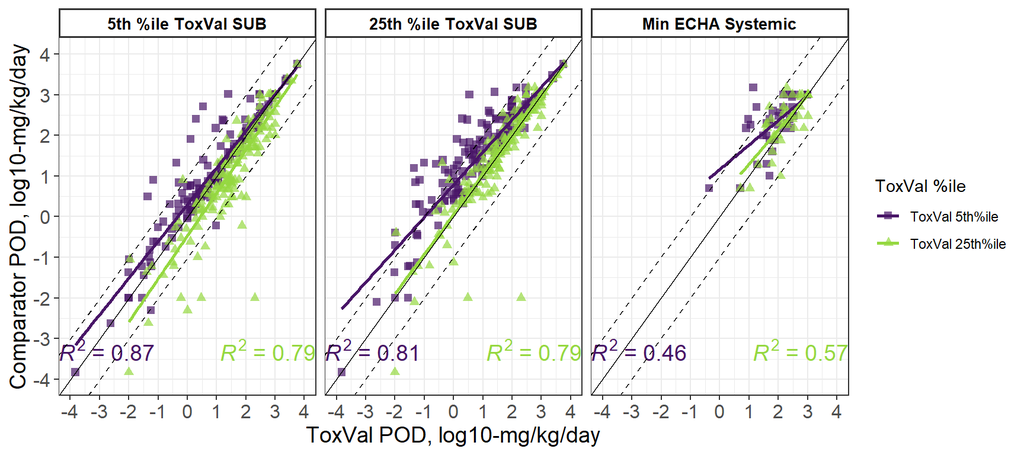

```r
# new facet labels
comparator.labels <- c('5th %ile ToxVal SUB',
                  '25th %ile ToxVal SUB',
                  'Min ECHA Systemic')
names(comparator.labels) <- c('p5.toxval.numeric.sub',
                                                     'p25.toxval.numeric.sub',
                                                     'log.ECHA_min_systemic_POD_mkd')


pod.lm <- ggplot(data=invivo.all.long,
                 aes(x=toxval.value,
                     y=comparator.value,
                     color=toxval, shape=toxval))+
  geom_point(aes(x=toxval.value,
                     y=comparator.value,
                     color=toxval, shape=toxval), alpha=0.7, size=2)+
  scale_color_manual(name='ToxVal %ile',
                     values=c('#481567FF','#95D840FF'),
                     labels=c('ToxVal 5th%ile', 'ToxVal 25th%ile'),
                     breaks = c('p5.toxval.numeric',
                                'p25.toxval.numeric'))+
  scale_shape_manual(name='ToxVal %ile',
                     values=c(15,17),
                     labels=c('ToxVal 5th%ile', 'ToxVal 25th%ile'),
                     breaks = c('p5.toxval.numeric',
                                'p25.toxval.numeric'))+
  scale_x_continuous(breaks=seq(-7, 5, 1))+
  scale_y_continuous(breaks=seq(-7, 5, 1))+
  coord_cartesian(xlim=c(-4,4), ylim=c(-4,4))+
  theme_bw()+
  geom_smooth(aes(group=toxval), method='lm',se=FALSE,formula=y~x)+
  stat_poly_eq(
               formula=y ~x,
               #eq.with.lhs = "y~`=`~",
               aes(label=paste0("atop(",..rr.label..,")")),
               parse=TRUE,
               #label.x=c(rep('right',3), 'left'),
               label.y=c(-2,-4),
               label.x=c(-3,1),
               size=5, face='bold')+
  geom_abline(slope=1, intercept=0) +
  geom_abline(slope=1, intercept=1, linetype="dashed") +
  geom_abline(slope=1, intercept=-1, linetype="dashed") +
  xlab('ToxVal POD, log10-mg/kg/day')+
  ylab('Comparator POD, log10-mg/kg/day')+
   theme(axis.text = element_text(size=12),
        axis.title = element_text(size=14))+
  facet_wrap(~comparator, scales='fixed', labeller = labeller(comparator=comparator.labels))+
  theme(strip.background = element_rect(fill='white',size=1),
        strip.text = element_text(size=10, color='black',face='bold'))

pod.lm
```

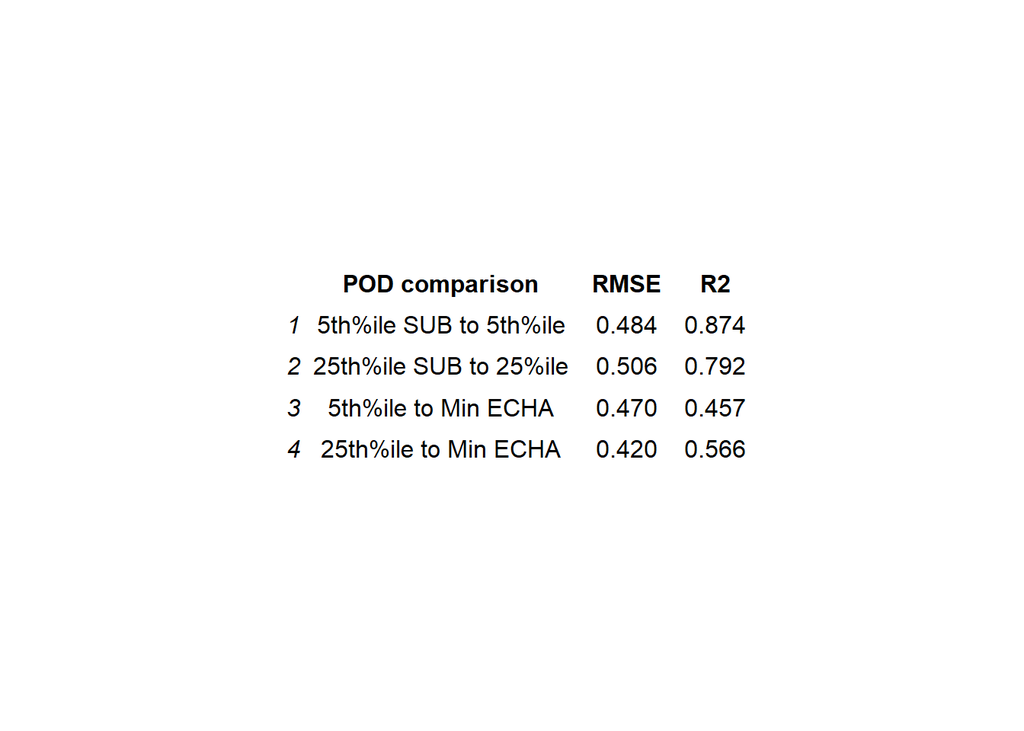

```r
mytheme <- gridExtra::ttheme_minimal(core=list(padding.v=unit(0.1, 'mm'), padding.h=unit(0.1,'mm')))
metric.grob <- grid.arrange(tableGrob(summ.pod, theme=mytheme))
```

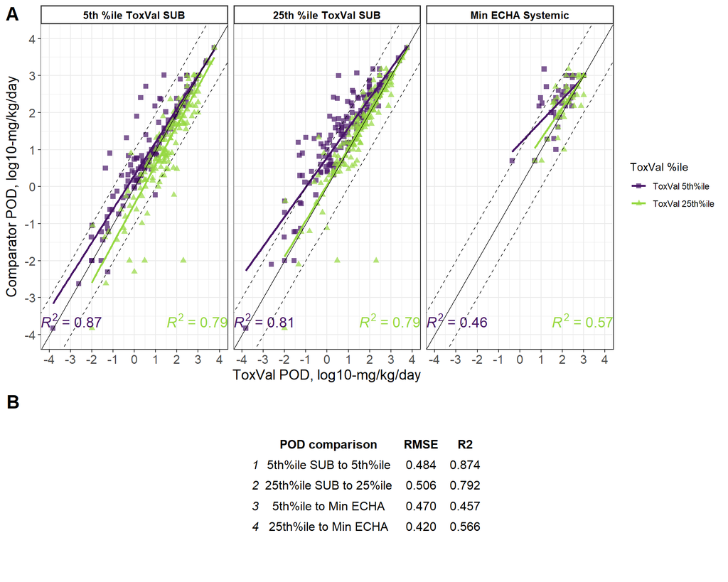

```r
fig.PODcomp <- plot_grid(pod.lm,metric.grob,labels=c("A", "B"), rel_heights = c(1,0.5), rel_widths = c(1,0.5), label_size=18, nrow=2)
fig.PODcomp
```

Merge in vivo PODs with primary data table.

```r
asnm.tier1.all.invivo <- merge.data.table(asnm.tier1.all,
                                          invivo.all[,c('dsstox_substance_id',
                                                        "data_poor_binary",
                                                        "ECHA_min_systemic_POD_mkd",
                                                        "log.ECHA_min_systemic_POD_mkd",
                                                        "log.repdose.90d.5th",
                                                        "log.repdose.90d.10th",
                                                        "log.repdose.90d.15th",
                                                        "log.repdose.90d.20th",
                                                        "log.repdose.90d.25th",
                                                        "log.repdose.90d.30th",
                                                        "log.repdose.any.5th",
                                                        "log.repdose.any.10th",
                                                        "log.repdose.any.15th",
                                                        "log.repdose.any.20th",
                                                        "log.repdose.any.25th",
                                                        "log.repdose.any.30th")],
                                          all.x = TRUE,
                                          by='dsstox_substance_id')
```

# 10 Comparison to TTC

## 10.1 in silico TTC

```r
# import TTC predictions
ttc <- as.data.table(read.xlsx('./source/chem/apcra_pro_TTC.xlsx', colNames = TRUE))
colnames(ttc)
```

```
## [1] "DTXSID"
## [2] "CASRN"
## [3] "preferred_name"
## [4] "CAN_SMILES"
## [5] "Toxic.hazard.classification.by.Cramer"
## [6] "TTC.(ug/kg.bw/day)"
```

```r
setnames(ttc, colnames(ttc), c('dtxsid','casrn','preferred_name','CAN_SMILES','Cramer','ug.kg.bw.day'))
ttc$ug.kg.bw.day <- as.numeric(ttc$ug.kg.bw.day)
```

```r
asnm.tier1.all.invivo <- merge.data.table(asnm.tier1.all.invivo,
                                       ttc[,c('dtxsid','ug.kg.bw.day')],
                                       by.y=c('dtxsid'),
                                       by.x=c('dsstox_substance_id'),
                                       all.x=TRUE)

asnm.tier1.all.invivo[,ttc := log10(ug.kg.bw.day/1000)]
asnm.tier1.all.invivo$chnm <- apcra.list$preferred_name[match(asnm.tier1.all.invivo$dsstox_substance_id,
                                                              apcra.list$DTXSID)]
```

```r
asnm.tier1.all.invivo[,pod.ratio := log.repdose.any.5th - med.aed50, by=dsstox_substance_id]
asnm.tier1.all.invivo[,ttc.ratio := log.repdose.any.5th - ttc, by=dsstox_substance_id]
asnm.tier1.all.invivo[,sub.ratio := log.repdose.any.5th - log.repdose.90d.5th, by=dsstox_substance_id]
```

```r
write.xlsx(asnm.tier1.all.invivo, file='./output/asnm_tier1_all_invivo.xlsx')
```

```r
kable(asnm.tier1.all.invivo[, c('log.repdose.any.5th',
                                    'med.aed50',
                                    'ttc',
                                    'log.repdose.90d.5th',
                                    'pod.ratio',
                                    'ttc.ratio',
                                    'sub.ratio')],
           filter='top',
          options=list(pagelength=25, autoWidth=FALSE,  scrollX=TRUE, initComplete = JS(
    "function(settings, json) {",
    "$('body').css({'font-family': 'Calibri'});",
    "}"
  )))
```

| log.repdose.any.5th | med.aed50 | ttc | log.repdose.90d.5th | pod.ratio | ttc.ratio | sub.ratio |
| --- | --- | --- | --- | --- | --- | --- |
| NA | 1.7926018 | -2.823909 | NA | NA | NA | NA |
| -1.1549020 | -0.8764750 | -2.823909 | -0.6161846 | -0.2784269 | 1.6690068 | -0.5387173 |
| 1.9242793 | 0.6215917 | -2.823909 | 1.9242793 | 1.3026876 | 4.7481880 | 0.0000000 |
| 0.6989700 | 1.5668894 | -2.823909 | 0.6989700 | -0.8679194 | 3.5228787 | 0.0000000 |
| 0.9786369 | -0.0525173 | -2.823909 | 0.9731279 | 1.0311542 | 3.8025457 | 0.0055091 |
| NA | -0.4750849 | -2.823909 | NA | NA | NA | NA |
| 3.3979400 | 1.5258220 | -1.522879 | 3.3979400 | 1.8721181 | 4.9208188 | 0.0000000 |
| 0.5468405 | -0.5922693 | -2.823909 | 1.4031205 | 1.1391098 | 3.3707493 | -0.8562800 |
| 0.0000000 | 1.8317939 | -2.823909 | 0.7403627 | -1.8317939 | 2.8239087 | -0.7403627 |
| 0.6989700 | 1.6307329 | -2.823909 | 1.2552725 | -0.9317629 | 3.5228787 | -0.5563025 |
| 0.6989700 | -0.5996347 | -2.823909 | 0.8750613 | 1.2986047 | 3.5228787 | -0.1760913 |
| 0.8061800 | 0.9572720 | -2.823909 | 1.0000000 | -0.1510920 | 3.6300887 | -0.1938200 |
| 0.1461280 | 0.6139475 | -2.823909 | 0.1746412 | -0.4678194 | 2.9700368 | -0.0285132 |
| -0.6020600 | 0.4272430 | -2.823909 | 0.3031961 | -1.0293030 | 2.2218487 | -0.9052560 |
| -3.8239087 | 0.4828736 | -2.823909 | -3.8239087 | -4.3067823 | -1.0000000 | 0.0000000 |
| NA | 1.5365482 | -2.823909 | NA | NA | NA | NA |
| NA | 0.1082267 | -2.823909 | NA | NA | NA | NA |
| 1.3010300 | 0.8578750 | -1.522879 | 1.3010300 | 0.4431550 | 2.8239087 | 0.0000000 |
| 2.6989700 | 1.6177192 | -1.522879 | 2.6989700 | 1.0812508 | 4.2218487 | 0.0000000 |
| -2.0000000 | 2.8806480 | NA | -2.0000000 | -4.8806480 | NA | 0.0000000 |
| 3.0000000 | -0.2435160 | NA | 3.0000000 | 3.2435160 | NA | 0.0000000 |
| 1.3979400 | -0.5270973 | -2.823909 | 1.3979400 | 1.9250374 | 4.2218487 | 0.0000000 |
| 2.9084850 | -1.3172234 | -2.823909 | 2.9084850 | 4.2257084 | 5.7323938 | 0.0000000 |
| NA | -2.4702518 | NA | NA | NA | NA | NA |
| 1.2787536 | 1.0453230 | -2.823909 | 1.2787536 | 0.2334306 | 4.1026623 | 0.0000000 |
| -0.5250557 | -0.7430418 | -2.823909 | -0.3010300 | 0.2179862 | 2.2988531 | -0.2240257 |
| 1.1760913 | 0.9714150 | -2.823909 | 1.1760913 | 0.2046762 | 4.0000000 | 0.0000000 |
| 1.5658478 | -1.5728386 | -1.522879 | 1.5658478 | 3.1386864 | 3.0887266 | 0.0000000 |
| -1.2498775 | 0.4687903 | -2.823909 | -2.3010300 | -1.7186677 | 1.5740313 | 1.0511525 |
| 0.3273589 | 0.8266491 | -2.823909 | 0.4771213 | -0.4992902 | 3.1512677 | -0.1497623 |

[output cut: 166 more lines]

```r
asnm.tier1.all.invivo.long <- melt.data.table(asnm.tier1.all.invivo,
                                         id.vars = c('dsstox_substance_id', 'chnm','log.repdose.any.5th',
                                    'med.aed50',
                                    'ttc',
                                    'log.repdose.90d.5th'),
                                         measure.vars = c(
                                    'pod.ratio',
                                    'ttc.ratio',
                                    'sub.ratio'),
                 variable.name = c('ratio.type'),
                 value.name = c('ratio'))
```

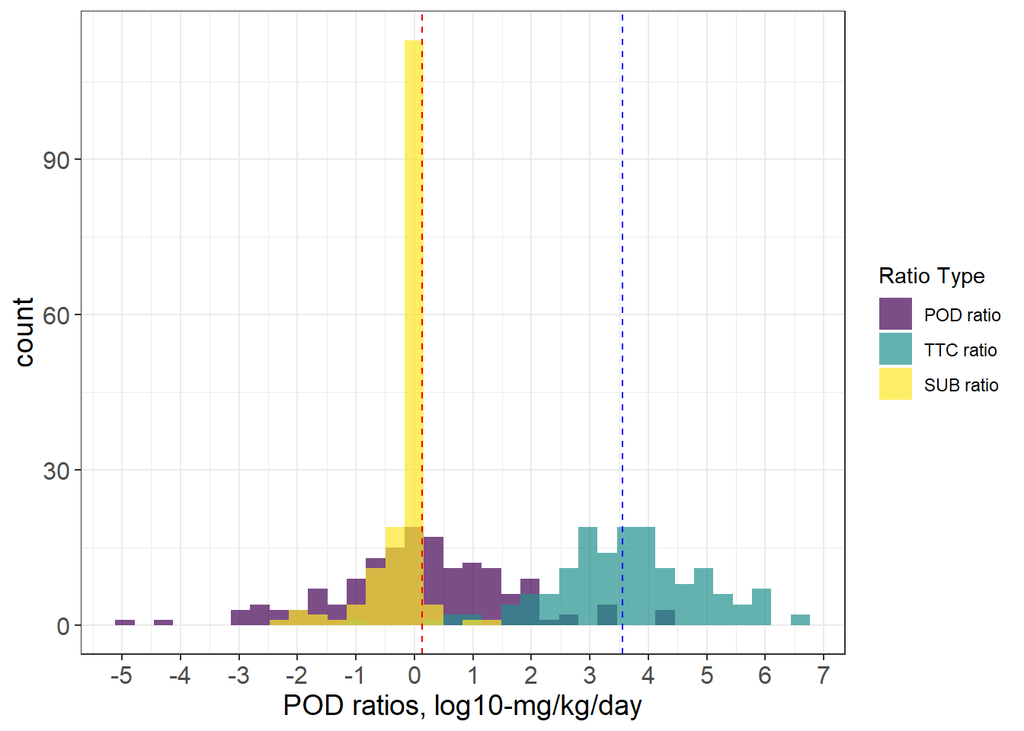

```r
pod.ratios <- ggplot(data=asnm.tier1.all.invivo.long, aes(x=ratio,fill=ratio.type))+
  geom_histogram(position='identity',binwidth = 0.33, alpha=0.7)+
  scale_x_continuous(breaks=seq(-5,10,1))+
  scale_fill_viridis(name='Ratio Type', discrete=TRUE, labels=c('POD ratio','TTC ratio','SUB ratio'))+
  #scale_color_viridis(discrete=TRUE)+
  theme_bw()+
  theme(axis.text = element_text(size=12),
        axis.title = element_text(size=14))+
  xlab("POD ratios, log10-mg/kg/day")+
  ylab("count")+
  #coord_cartesian(xlim=c(0,6))+
  geom_vline(xintercept=median(asnm.tier1.all.invivo$pod.ratio, na.rm=TRUE), col='red', linetype='dashed')+
  geom_vline(xintercept=median(asnm.tier1.all.invivo$ttc.ratio, na.rm=TRUE), col='blue', linetype='dashed')

pod.ratios
```

```r
asnm.tier1.all.invivo[pod.ratio > 3, pod.ratio.size := as.character('med.aed50 too small')]
asnm.tier1.all.invivo[pod.ratio < -3, pod.ratio.size := as.character('med.aed50 too big')]

large.delta.pod.ratio <- asnm.tier1.all.invivo[pod.ratio.size %in% c('med.aed50 too small','med.aed50 too big'), c('chnm','dsstox_substance_id',
                                                                                                                   'log.repdose.any.5th',
                                    'med.aed50',
                                    'pod.ratio')]


setnames(large.delta.pod.ratio, c(1:5), c('chnm','DTXSID','5th%ile POD-trad','Med AED50','POD ratio'))
large.delta.pod.ratio[, `5th%ile POD-trad` := round(`5th%ile POD-trad`, 2)]
large.delta.pod.ratio[, `Med AED50` := round(`Med AED50`, 2)]
large.delta.pod.ratio[, `POD ratio` := round(`POD ratio`, 2)]
large.delta.pod.ratio <- large.delta.pod.ratio[order(`POD ratio`)]

cols <- matrix(c("#000000"),nrow(large.delta.pod.ratio), ncol(large.delta.pod.ratio))
tt <- ttheme_minimal(
  core=list(fg_params = list(col = cols, cex=1.0),
            bg_params = list(col=NA)),
  rowhead=list(bg_params = list(col=NA), fg_params = list(fontface = "bold",
                                                          cex=1.0)),
  colhead=list(bg_params = list(col=NA), fg_params = list(cex=1.0)))
t.podratio <- tableGrob(large.delta.pod.ratio, theme = tt)
```

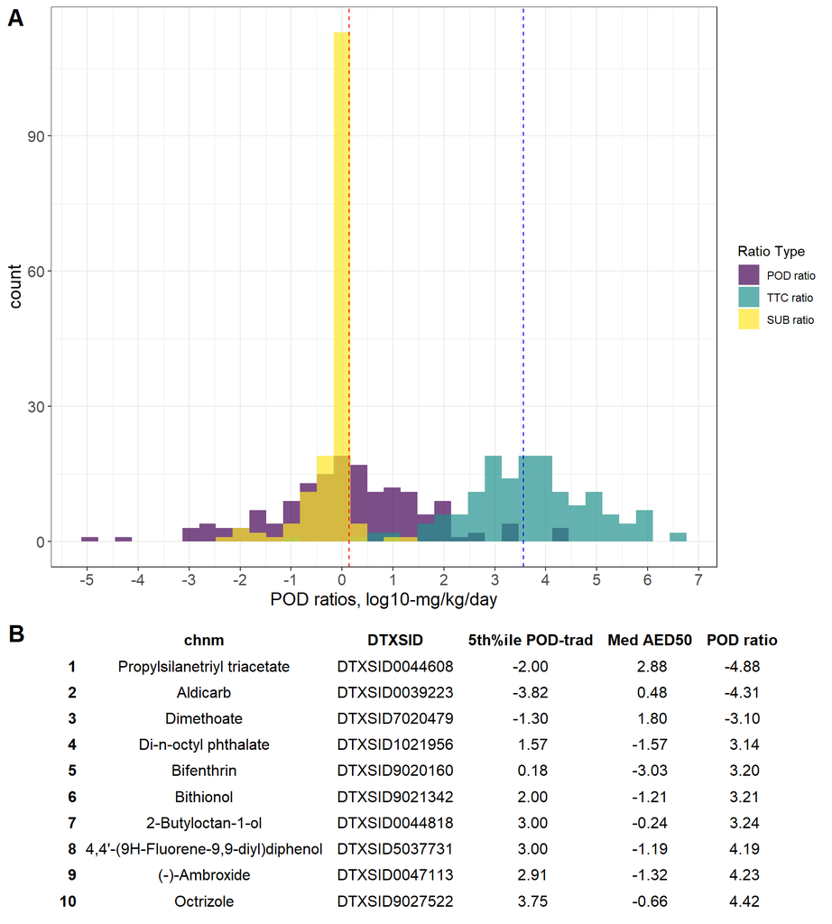

```r
plot_grid(pod.ratios, t.podratio, labels = c('A', 'B'), label_size = 18, nrow =2, rel_heights = c(1, 0.5))
```

```r
file.dir <- paste('output/', sep='')
file.name <- paste('/Fig6_PODratios_comp_', Sys.Date(), '.tiff', sep='')
file.path <- paste(file.dir, file.name, sep='')
dir.create(path=file.dir, showWarnings = FALSE, recursive = TRUE)
tiff(file.path, width=8, height=9, units='in', res=450)
plot_grid(pod.ratios, t.podratio, labels = c('A', 'B'), label_size = 18, nrow =2, rel_heights = c(1, 0.5))
dev.off()
```

# 11 ECDF Plots of POD ratios

The purpose of this section is to calculate ratios by assay technology or by technology type (targeted, broad, hipptox). Then we want to examine the use of these data in the POD ratio calculation via an empirical cumulative distribution plot(s). 32 chemicals do not have any repeat dose POD (164 have it).

```r
#asnm.tier1.all.invivo <- as.data.table(read.xlsx('./output/asnm_tier1_all_invivo.xlsx', colNames = TRUE,na.strings='NA'))
colnames(asnm.tier1.all.invivo)
```

```
##  [1] "dsstox_substance_id"
##  [2] "aed50.3compss.5pacc"
##  [3] "aed50.3compss.atg"
##  [4] "aed50.3compss.bsk"
##  [5] "aed50.3compss.ccte"
##  [6] "aed50.3compss.nvs"
##  [7] "aed50.3compss.stm"
##  [8] "aed50.3compss.httr.mcf7.sigbmd"
##  [9] "aed50.3compss.httr.u2os.sigbmd"
## [10] "aed50.3compss.httr.heparg.sigbmd"
## [11] "aed50.3compss.htpp.u2os"
## [12] "aed50.3compss.astar.beas2b"
## [13] "aed50.3compss.astar.hepg2"
## [14] "aed50.3compss.astar.hek293"
## [15] "aed50.pbtk.5pacc"
```

[output cut: 82 more lines]

```r
#asnm.tier1.all.ratios <- asnm.tier1.all.invivo[,c(1,29:46, 59:61, 64, 67:68)] # need to reduce the col number of the data.table
asnm.tier1.all.invivo[is.na(log.repdose.any.5th)] # 32 rows
```

| dsstox_substance_id | aed50.3compss.5pacc | aed50.3compss.atg | aed50.3compss.bsk | aed50.3compss.ccte | aed50.3compss.nvs | aed50.3compss.stm | aed50.3compss.httr.mcf7.sigbmd | aed50.3compss.httr.u2os.sigbmd | aed50.3compss.httr.heparg.sigbmd | aed50.3compss.htpp.u2os | aed50.3compss.astar.beas2b | aed50.3compss.astar.hepg2 | aed50.3compss.astar.hek293 | aed50.pbtk.5pacc | aed50.pbtk.atg | aed50.pbtk.bsk | aed50.pbtk.ccte | aed50.pbtk.nvs | aed50.pbtk.stm | aed50.pbtk.httr.mcf7.sigbmd | aed50.pbtk.httr.u2os.sigbmd | aed50.pbtk.httr.heparg.sigbmd | aed50.pbtk.htpp.u2os | aed50.pbtk.astar.beas2b | aed50.pbtk.astar.hepg2 | aed50.pbtk.astar.hek293 | the.day | aed50.atg | aed50.bsk | … |
| --- | --- | --- | --- | --- | --- | --- | --- | --- | --- | --- | --- | --- | --- | --- | --- | --- | --- | --- | --- | --- | --- | --- | --- | --- | --- | --- | --- | --- | --- | --- |
| DTXSID0020284 | 1.3611610 | 0.61762930 | 1.14176323 | 1.9393195 | NA | 1.3326404 | NA | 1.41480628 | 1.8155113 | 1.823213313 | 2.9901612 | 3.3172273 | 3.1640553 | 1.44978685 | 0.66651798 | 1.21906033 | 1.9582771 | NA | 1.370143 | NA | 1.43184605 | 1.7926018 | 1.813714392 | 3.008174 | 3.3613500 | 3.1809856 | 0 | 0.66651798 | 1.21906033 | … |
| DTXSID0022436 | -1.4289903 | -0.62433639 | NA | NA | -1.00313823 | -2.1522423 | NA | -0.15689186 | 1.9306944 | NA | NA | NA | NA | -1.28802415 | -0.47508485 | NA | NA | -1.012736046 | -2.145998 | NA | -0.18435585 | 1.9366645 | NA | NA | NA | NA | 2 | -0.47508485 | NA | … |
| DTXSID0040127 | -1.2792620 | 1.62034430 | NA | -2.4174821 | NA | NA | NA | 1.48201558 | 3.0346285 | 1.306639441 | NA | NA | NA | -1.28508375 | 1.63265971 | NA | -2.4158950 | NA | NA | NA | 1.44043677 | 3.0187005 | 1.331224781 | NA | NA | NA | 0 | 1.63265971 | NA | … |
| DTXSID0040707 | -0.2540668 | -0.14825258 | -0.05843888 | NA | -2.61314447 | NA | 0.4598446 | -0.48891915 | 2.2216750 | -0.613144471 | NA | 1.1525941 | 1.7358383 | -0.07001941 | 0.02694163 | 0.10822666 | NA | -2.595679533 | NA | 0.4559102 | -0.47625353 | 2.2289134 | -0.618523910 | NA | 1.1878026 | 1.7041505 | 0 | 0.02694163 | 0.10822666 | … |
| DTXSID0048505 | -3.3198459 | -2.99310629 | -2.41273815 | NA | -6.46344156 | -2.1195294 | -2.0306773 | -2.76674999 | -2.1880231 | -3.623788150 | NA | NA | NA | -3.10138450 | -2.79371396 | -2.19287104 | NA | -6.442492798 | -2.166152 | -2.0588365 | -2.74763249 | -2.1909793 | -3.614751318 | NA | NA | NA | 114 | -2.79371396 | -2.19287104 | … |
| DTXSID1025302 | 0.1401937 | NA | -0.26408188 | NA | NA | NA | 0.5587086 | 0.22737244 | 0.8256208 | -0.009972101 | 1.7584577 | 1.6433540 | NA | 0.30427505 | NA | -0.07935500 | NA | NA | NA | 0.5764565 | 0.23628528 | 0.7907073 | 0.008600172 | 1.717421 | 1.6860998 | NA | 5 | NA | -0.07935500 | … |
| DTXSID1036541 | -0.3426573 | -0.04978123 | 0.64345268 | -1.4277094 | NA | NA | 0.9257245 | 1.03302144 | 1.5285311 | 0.825620825 | NA | 1.6237660 | NA | -0.17842097 | 0.15014216 | 0.76849011 | -1.4121768 | NA | NA | 0.9500239 | 1.00860017 | 1.4886917 | 0.843606472 | NA | 1.6207605 | NA | 0 | 0.15014216 | 0.76849011 | … |
| DTXSID1044354 | 1.3782161 | NA | NA | 1.3684728 | NA | NA | NA | 1.44090908 | 2.9922441 | NA | 2.5949447 | NA | NA | 1.28712962 | NA | NA | 1.3895205 | NA | NA | NA | 1.42390092 | 2.9914033 | NA | 2.599446 | NA | NA | 0 | NA | NA | … |
| DTXSID1044934 | 0.1690864 | NA | NA | NA | NA | NA | NA | 1.03302144 | 2.8927622 | NA | NA | NA | NA | 0.25139485 | NA | NA | NA | NA | NA | NA | 1.02694163 | 2.9139727 | NA | NA | NA | NA | NA | NA | NA | … |
| DTXSID1046970 | -0.1771784 | -1.02788977 | -0.21034879 | NA | -0.50473326 | 0.7624535 | 1.1798389 | 0.29070224 | 2.8353735 | 0.337658891 | 1.6981005 | 1.6082050 | 1.6751365 | -0.01565274 | -0.84466396 | -0.01242311 | NA | -0.522734005 | 0.793511 | 1.1604685 | 0.32551566 | 2.7991337 | 0.324076580 | 1.686368 | 1.6082050 | 1.6796096 | 0 | -0.84466396 | -0.01242311 | … |

[output cut: 22 more lines]

All median and minimum battery POD ratios

```r
asnm.tier1.all.invivo[,pod.ratio10 := log.repdose.any.10th - med.aed50, by=dsstox_substance_id]
asnm.tier1.all.invivo[,pod.ratio15 := log.repdose.any.15th - med.aed50, by=dsstox_substance_id]
asnm.tier1.all.invivo[,pod.ratio20 := log.repdose.any.20th - med.aed50, by=dsstox_substance_id]
asnm.tier1.all.invivo[,pod.ratio25 := log.repdose.any.25th - med.aed50, by=dsstox_substance_id]
asnm.tier1.all.invivo[,pod.ratio30 := log.repdose.any.30th - med.aed50, by=dsstox_substance_id]

asnm.tier1.all.invivo[,pod.min.ratio5 := log.repdose.any.5th - min.aed50, by=dsstox_substance_id]
asnm.tier1.all.invivo[,pod.min.ratio10 := log.repdose.any.10th - min.aed50, by=dsstox_substance_id]
asnm.tier1.all.invivo[,pod.min.ratio15 := log.repdose.any.15th - min.aed50, by=dsstox_substance_id]
asnm.tier1.all.invivo[,pod.min.ratio20 := log.repdose.any.20th - min.aed50, by=dsstox_substance_id]
asnm.tier1.all.invivo[,pod.min.ratio25 := log.repdose.any.25th - min.aed50, by=dsstox_substance_id]
asnm.tier1.all.invivo[,pod.min.ratio30 := log.repdose.any.30th - min.aed50, by=dsstox_substance_id]

asnm.tier1.all.ratios <- as.data.table(asnm.tier1.all.invivo)
```

Calculate ratios by specific assay technology, in the form log10(podtraditional - podnam). All of these values are already in log10 units.

Targeted technologies to all ToxVal %iles

```r
## targeted technologies to 5th%ile POD

asnm.tier1.all.ratios <- asnm.tier1.all.ratios %>% rowwise() %>% mutate(ratio5.atg=log.repdose.any.5th - aed50.atg,na.rm=TRUE) %>% data.table()
asnm.tier1.all.ratios <- asnm.tier1.all.ratios %>% rowwise() %>% mutate(ratio5.biomap=log.repdose.any.5th - aed50.bsk,na.rm=TRUE) %>% data.table()
asnm.tier1.all.ratios <- asnm.tier1.all.ratios %>% rowwise() %>% mutate(ratio5.mea=log.repdose.any.5th - aed50.ccte,na.rm=TRUE) %>% data.table()
asnm.tier1.all.ratios <- asnm.tier1.all.ratios %>% rowwise() %>% mutate(ratio5.nvs=log.repdose.any.5th - aed50.nvs,na.rm=TRUE) %>% data.table()
asnm.tier1.all.ratios <- asnm.tier1.all.ratios %>% rowwise() %>% mutate(ratio5.stm=log.repdose.any.5th - aed50.stm,na.rm=TRUE) %>% data.table()

## targeted technologies to 10th%ile POD

asnm.tier1.all.ratios <- asnm.tier1.all.ratios %>% rowwise() %>% mutate(ratio10.atg=log.repdose.any.10th - aed50.atg,na.rm=TRUE) %>% data.table()
asnm.tier1.all.ratios <- asnm.tier1.all.ratios %>% rowwise() %>% mutate(ratio10.biomap=log.repdose.any.10th - aed50.bsk,na.rm=TRUE) %>% data.table()
asnm.tier1.all.ratios <- asnm.tier1.all.ratios %>% rowwise() %>% mutate(ratio10.mea=log.repdose.any.10th - aed50.ccte,na.rm=TRUE) %>% data.table()
asnm.tier1.all.ratios <- asnm.tier1.all.ratios %>% rowwise() %>% mutate(ratio10.nvs=log.repdose.any.10th - aed50.nvs,na.rm=TRUE) %>% data.table()
asnm.tier1.all.ratios <- asnm.tier1.all.ratios %>% rowwise() %>% mutate(ratio10.stm=log.repdose.any.10th - aed50.stm,na.rm=TRUE) %>% data.table()

## targeted technologies to 15th%ile POD

asnm.tier1.all.ratios <- asnm.tier1.all.ratios %>% rowwise() %>% mutate(ratio15.atg=log.repdose.any.15th - aed50.atg,na.rm=TRUE) %>% data.table()
asnm.tier1.all.ratios <- asnm.tier1.all.ratios %>% rowwise() %>% mutate(ratio15.biomap=log.repdose.any.15th - aed50.bsk,na.rm=TRUE) %>% data.table()
asnm.tier1.all.ratios <- asnm.tier1.all.ratios %>% rowwise() %>% mutate(ratio15.mea=log.repdose.any.15th - aed50.ccte,na.rm=TRUE) %>% data.table()
asnm.tier1.all.ratios <- asnm.tier1.all.ratios %>% rowwise() %>% mutate(ratio15.nvs=log.repdose.any.15th - aed50.nvs,na.rm=TRUE) %>% data.table()
asnm.tier1.all.ratios <- asnm.tier1.all.ratios %>% rowwise() %>% mutate(ratio15.stm=log.repdose.any.15th - aed50.stm,na.rm=TRUE) %>% data.table()

## targeted technologies to 20th%ile POD

asnm.tier1.all.ratios <- asnm.tier1.all.ratios %>% rowwise() %>% mutate(ratio20.atg=log.repdose.any.20th - aed50.atg,na.rm=TRUE) %>% data.table()
asnm.tier1.all.ratios <- asnm.tier1.all.ratios %>% rowwise() %>% mutate(ratio20.biomap=log.repdose.any.20th - aed50.bsk,na.rm=TRUE) %>% data.table()
asnm.tier1.all.ratios <- asnm.tier1.all.ratios %>% rowwise() %>% mutate(ratio20.mea=log.repdose.any.20th - aed50.ccte,na.rm=TRUE) %>% data.table()
asnm.tier1.all.ratios <- asnm.tier1.all.ratios %>% rowwise() %>% mutate(ratio20.nvs=log.repdose.any.20th - aed50.nvs,na.rm=TRUE) %>% data.table()
asnm.tier1.all.ratios <- asnm.tier1.all.ratios %>% rowwise() %>% mutate(ratio20.stm=log.repdose.any.20th - aed50.stm,na.rm=TRUE) %>% data.table()

## targeted technologies to 25th%ile POD

asnm.tier1.all.ratios <- asnm.tier1.all.ratios %>% rowwise() %>% mutate(ratio25.atg=log.repdose.any.25th - aed50.atg,na.rm=TRUE) %>% data.table()
asnm.tier1.all.ratios <- asnm.tier1.all.ratios %>% rowwise() %>% mutate(ratio25.biomap=log.repdose.any.25th - aed50.bsk,na.rm=TRUE) %>% data.table()
asnm.tier1.all.ratios <- asnm.tier1.all.ratios %>% rowwise() %>% mutate(ratio25.mea=log.repdose.any.25th - aed50.ccte,na.rm=TRUE) %>% data.table()
asnm.tier1.all.ratios <- asnm.tier1.all.ratios %>% rowwise() %>% mutate(ratio25.nvs=log.repdose.any.25th - aed50.nvs,na.rm=TRUE) %>% data.table()
asnm.tier1.all.ratios <- asnm.tier1.all.ratios %>% rowwise() %>% mutate(ratio25.stm=log.repdose.any.25th - aed50.stm,na.rm=TRUE) %>% data.table()

## targeted technologies to 30th%ile POD

asnm.tier1.all.ratios <- asnm.tier1.all.ratios %>% rowwise() %>% mutate(ratio30.atg=log.repdose.any.30th - aed50.atg,na.rm=TRUE) %>% data.table()
asnm.tier1.all.ratios <- asnm.tier1.all.ratios %>% rowwise() %>% mutate(ratio30.biomap=log.repdose.any.30th - aed50.bsk,na.rm=TRUE) %>% data.table()
asnm.tier1.all.ratios <- asnm.tier1.all.ratios %>% rowwise() %>% mutate(ratio30.mea=log.repdose.any.30th - aed50.ccte,na.rm=TRUE) %>% data.table()
asnm.tier1.all.ratios <- asnm.tier1.all.ratios %>% rowwise() %>% mutate(ratio30.nvs=log.repdose.any.30th - aed50.nvs,na.rm=TRUE) %>% data.table()
asnm.tier1.all.ratios <- asnm.tier1.all.ratios %>% rowwise() %>% mutate(ratio30.stm=log.repdose.any.30th - aed50.stm,na.rm=TRUE) %>% data.table()
```

Broad technologies to all ToxVal %iles

```r
## broad technologies to 5th%ile POD

asnm.tier1.all.ratios <- asnm.tier1.all.ratios %>% rowwise() %>% mutate(ratio5.httr.mcf7=log.repdose.any.5th - aed50.httr.mcf7,na.rm=TRUE) %>% data.table()
asnm.tier1.all.ratios <- asnm.tier1.all.ratios %>% rowwise() %>% mutate(ratio5.httr.u2os=log.repdose.any.5th - aed50.httr.u2os,na.rm=TRUE) %>% data.table()
asnm.tier1.all.ratios <- asnm.tier1.all.ratios %>% rowwise() %>% mutate(ratio5.httr.heparg=log.repdose.any.5th - aed50.httr.heparg,na.rm=TRUE) %>% data.table()
asnm.tier1.all.ratios <- asnm.tier1.all.ratios %>% rowwise() %>% mutate(ratio5.htpp.u2os=log.repdose.any.5th - aed50.htpp.u2os,na.rm=TRUE) %>% data.table()

## broad technologies to 10th%ile POD

asnm.tier1.all.ratios <- asnm.tier1.all.ratios %>% rowwise() %>% mutate(ratio10.httr.mcf7=log.repdose.any.10th - aed50.httr.mcf7,na.rm=TRUE) %>% data.table()
asnm.tier1.all.ratios <- asnm.tier1.all.ratios %>% rowwise() %>% mutate(ratio10.httr.u2os=log.repdose.any.10th - aed50.httr.u2os,na.rm=TRUE) %>% data.table()
asnm.tier1.all.ratios <- asnm.tier1.all.ratios %>% rowwise() %>% mutate(ratio10.httr.heparg=log.repdose.any.10th - aed50.httr.heparg,na.rm=TRUE) %>% data.table()
asnm.tier1.all.ratios <- asnm.tier1.all.ratios %>% rowwise() %>% mutate(ratio10.htpp.u2os=log.repdose.any.10th - aed50.htpp.u2os,na.rm=TRUE) %>% data.table()

## broad technologies to 15th%ile POD

asnm.tier1.all.ratios <- asnm.tier1.all.ratios %>% rowwise() %>% mutate(ratio15.httr.mcf7=log.repdose.any.15th - aed50.httr.mcf7,na.rm=TRUE) %>% data.table()
asnm.tier1.all.ratios <- asnm.tier1.all.ratios %>% rowwise() %>% mutate(ratio15.httr.u2os=log.repdose.any.15th - aed50.httr.u2os,na.rm=TRUE) %>% data.table()
asnm.tier1.all.ratios <- asnm.tier1.all.ratios %>% rowwise() %>% mutate(ratio15.httr.heparg=log.repdose.any.15th - aed50.httr.heparg,na.rm=TRUE) %>% data.table()
asnm.tier1.all.ratios <- asnm.tier1.all.ratios %>% rowwise() %>% mutate(ratio15.htpp.u2os=log.repdose.any.15th - aed50.htpp.u2os,na.rm=TRUE) %>% data.table()

## broad technologies to 20th%ile POD

asnm.tier1.all.ratios <- asnm.tier1.all.ratios %>% rowwise() %>% mutate(ratio20.httr.mcf7=log.repdose.any.20th - aed50.httr.mcf7,na.rm=TRUE) %>% data.table()
asnm.tier1.all.ratios <- asnm.tier1.all.ratios %>% rowwise() %>% mutate(ratio20.httr.u2os=log.repdose.any.20th - aed50.httr.u2os,na.rm=TRUE) %>% data.table()
asnm.tier1.all.ratios <- asnm.tier1.all.ratios %>% rowwise() %>% mutate(ratio20.httr.heparg=log.repdose.any.20th - aed50.httr.heparg,na.rm=TRUE) %>% data.table()
asnm.tier1.all.ratios <- asnm.tier1.all.ratios %>% rowwise() %>% mutate(ratio20.htpp.u2os=log.repdose.any.20th - aed50.htpp.u2os,na.rm=TRUE) %>% data.table()

## broad technologies to 25th%ile POD

asnm.tier1.all.ratios <- asnm.tier1.all.ratios %>% rowwise() %>% mutate(ratio25.httr.mcf7=log.repdose.any.25th - aed50.httr.mcf7,na.rm=TRUE) %>% data.table()
asnm.tier1.all.ratios <- asnm.tier1.all.ratios %>% rowwise() %>% mutate(ratio25.httr.u2os=log.repdose.any.25th - aed50.httr.u2os,na.rm=TRUE) %>% data.table()
asnm.tier1.all.ratios <- asnm.tier1.all.ratios %>% rowwise() %>% mutate(ratio25.httr.heparg=log.repdose.any.25th - aed50.httr.heparg,na.rm=TRUE) %>% data.table()
asnm.tier1.all.ratios <- asnm.tier1.all.ratios %>% rowwise() %>% mutate(ratio25.htpp.u2os=log.repdose.any.25th - aed50.htpp.u2os,na.rm=TRUE) %>% data.table()

## broad technologies to 30th%ile POD

asnm.tier1.all.ratios <- asnm.tier1.all.ratios %>% rowwise() %>% mutate(ratio30.httr.mcf7=log.repdose.any.30th - aed50.httr.mcf7,na.rm=TRUE) %>% data.table()
asnm.tier1.all.ratios <- asnm.tier1.all.ratios %>% rowwise() %>% mutate(ratio30.httr.u2os=log.repdose.any.30th - aed50.httr.u2os,na.rm=TRUE) %>% data.table()
asnm.tier1.all.ratios <- asnm.tier1.all.ratios %>% rowwise() %>% mutate(ratio30.httr.heparg=log.repdose.any.30th - aed50.httr.heparg,na.rm=TRUE) %>% data.table()
asnm.tier1.all.ratios <- asnm.tier1.all.ratios %>% rowwise() %>% mutate(ratio30.htpp.u2os=log.repdose.any.30th - aed50.htpp.u2os,na.rm=TRUE) %>% data.table()
```

ASTAR assays to all ToxVal %iles

```r
## astar hipptox to 5th%ile POD

asnm.tier1.all.ratios <- asnm.tier1.all.ratios %>% rowwise() %>% mutate(ratio5.hipptox.beas2b=log.repdose.any.5th - aed50.astar.beas2b,na.rm=TRUE) %>% data.table()
asnm.tier1.all.ratios <- asnm.tier1.all.ratios %>% rowwise() %>% mutate(ratio5.hipptox.hepg2=log.repdose.any.5th - aed50.astar.hepg2,na.rm=TRUE) %>% data.table()
asnm.tier1.all.ratios <- asnm.tier1.all.ratios %>% rowwise() %>% mutate(ratio5.hipptox.hk2=log.repdose.any.5th - aed50.astar.hek293,na.rm=TRUE) %>% data.table()

## astar hipptox to 10th%ile POD

asnm.tier1.all.ratios <- asnm.tier1.all.ratios %>% rowwise() %>% mutate(ratio10.hipptox.beas2b=log.repdose.any.10th - aed50.astar.beas2b,na.rm=TRUE) %>% data.table()
asnm.tier1.all.ratios <- asnm.tier1.all.ratios %>% rowwise() %>% mutate(ratio10.hipptox.hepg2=log.repdose.any.10th - aed50.astar.hepg2,na.rm=TRUE) %>% data.table()
asnm.tier1.all.ratios <- asnm.tier1.all.ratios %>% rowwise() %>% mutate(ratio10.hipptox.hk2=log.repdose.any.10th - aed50.astar.hek293,na.rm=TRUE) %>% data.table()

## astar hipptox to 5th%ile POD

asnm.tier1.all.ratios <- asnm.tier1.all.ratios %>% rowwise() %>% mutate(ratio15.hipptox.beas2b=log.repdose.any.15th - aed50.astar.beas2b,na.rm=TRUE) %>% data.table()
asnm.tier1.all.ratios <- asnm.tier1.all.ratios %>% rowwise() %>% mutate(ratio15.hipptox.hepg2=log.repdose.any.15th - aed50.astar.hepg2,na.rm=TRUE) %>% data.table()
asnm.tier1.all.ratios <- asnm.tier1.all.ratios %>% rowwise() %>% mutate(ratio15.hipptox.hk2=log.repdose.any.15th - aed50.astar.hek293,na.rm=TRUE) %>% data.table()

## astar hipptox to 5th%ile POD

asnm.tier1.all.ratios <- asnm.tier1.all.ratios %>% rowwise() %>% mutate(ratio20.hipptox.beas2b=log.repdose.any.20th - aed50.astar.beas2b,na.rm=TRUE) %>% data.table()
asnm.tier1.all.ratios <- asnm.tier1.all.ratios %>% rowwise() %>% mutate(ratio20.hipptox.hepg2=log.repdose.any.20th - aed50.astar.hepg2,na.rm=TRUE) %>% data.table()
asnm.tier1.all.ratios <- asnm.tier1.all.ratios %>% rowwise() %>% mutate(ratio20.hipptox.hk2=log.repdose.any.20th - aed50.astar.hek293,na.rm=TRUE) %>% data.table()

## astar hipptox to 25th %ile POD

asnm.tier1.all.ratios <- asnm.tier1.all.ratios %>% rowwise() %>% mutate(ratio25.hipptox.beas2b=log.repdose.any.25th - aed50.astar.beas2b,na.rm=TRUE) %>% data.table()
asnm.tier1.all.ratios <- asnm.tier1.all.ratios %>% rowwise() %>% mutate(ratio25.hipptox.hepg2=log.repdose.any.25th - aed50.astar.hepg2,na.rm=TRUE) %>% data.table()
asnm.tier1.all.ratios <- asnm.tier1.all.ratios %>% rowwise() %>% mutate(ratio25.hipptox.hk2=log.repdose.any.25th - aed50.astar.hek293,na.rm=TRUE) %>% data.table()

## astar hipptox to 30th%ile POD

asnm.tier1.all.ratios <- asnm.tier1.all.ratios %>% rowwise() %>% mutate(ratio30.hipptox.beas2b=log.repdose.any.30th - aed50.astar.beas2b,na.rm=TRUE) %>% data.table()
asnm.tier1.all.ratios <- asnm.tier1.all.ratios %>% rowwise() %>% mutate(ratio30.hipptox.hepg2=log.repdose.any.30th - aed50.astar.hepg2,na.rm=TRUE) %>% data.table()
asnm.tier1.all.ratios <- asnm.tier1.all.ratios %>% rowwise() %>% mutate(ratio30.hipptox.hk2=log.repdose.any.30th - aed50.astar.hek293,na.rm=TRUE) %>% data.table()
```

MLR ratios

```r
asnm.tier1.all.ratios <- asnm.tier1.all.ratios %>% rowwise() %>% mutate(ratio5.mlr5=log.repdose.any.5th - mlr.toxval5.aed50,na.rm=TRUE) %>% data.table()
asnm.tier1.all.ratios <- asnm.tier1.all.ratios %>% rowwise() %>% mutate(ratio25.mlr25=log.repdose.any.25th - mlr.toxval25.aed50,na.rm=TRUE) %>% data.table()
```

```r
setnames(asnm.tier1.all.ratios, c('pod.ratio'), c('pod.ratio5'))
```

Add calculation of %ile ratios by median assay type (broad, targeted, hipptox, broad+targeted).

Minimum targeted AED values for POD ratios.

```r
asnm.tier1.all.ratios <- asnm.tier1.all.ratios %>% rowwise() %>% mutate(ratio5.min.target=min(c(ratio5.atg,
                                                                                                  ratio5.biomap,
                                                                                                  #ratio5.mea,
                                                                                                  ratio5.nvs,
                                                                                                  ratio5.stm), na.rm=TRUE)) %>% data.table()

asnm.tier1.all.ratios <- asnm.tier1.all.ratios %>% rowwise() %>% mutate(ratio10.min.target=min(c(ratio10.atg,
                                                                                                  ratio10.biomap,
                                                                                                  #ratio5.mea,
                                                                                                  ratio10.nvs,
                                                                                                  ratio10.stm), na.rm=TRUE)) %>% data.table()

asnm.tier1.all.ratios <- asnm.tier1.all.ratios %>% rowwise() %>% mutate(ratio15.min.target=min(c(ratio15.atg,
                                                                                                  ratio15.biomap,
                                                                                                  #ratio5.mea,
                                                                                                  ratio15.nvs,
                                                                                                  ratio15.stm), na.rm=TRUE)) %>% data.table()

asnm.tier1.all.ratios <- asnm.tier1.all.ratios %>% rowwise() %>% mutate(ratio20.min.target=min(c(ratio20.atg,
                                                                                                  ratio20.biomap,
                                                                                                  #ratio5.mea,
                                                                                                  ratio20.nvs,
                                                                                                  ratio20.stm), na.rm=TRUE)) %>% data.table()

asnm.tier1.all.ratios <- asnm.tier1.all.ratios %>% rowwise() %>% mutate(ratio25.min.target=min(c(ratio25.atg,
                                                                                                  ratio25.biomap,
                                                                                                  #ratio5.mea,
                                                                                                  ratio25.nvs,
                                                                                                  ratio25.stm), na.rm=TRUE)) %>% data.table()

asnm.tier1.all.ratios <- asnm.tier1.all.ratios %>% rowwise() %>% mutate(ratio30.min.target=min(c(ratio30.atg,
                                                                                                  ratio30.biomap,
                                                                                                  #ratio5.mea,
                                                                                                  ratio30.nvs,
                                                                                                  ratio30.stm), na.rm=TRUE)) %>% data.table()
```

Median targeted AED values for POD ratios

```r
asnm.tier1.all.ratios <- asnm.tier1.all.ratios %>% rowwise() %>% mutate(ratio5.med.target=median(c(ratio5.atg,
                                                                                                  ratio5.biomap,
                                                                                                  #ratio5.mea,
                                                                                                  ratio5.nvs,
                                                                                                  ratio5.stm), na.rm=TRUE)) %>% data.table()

asnm.tier1.all.ratios <- asnm.tier1.all.ratios %>% rowwise() %>% mutate(ratio10.med.target=median(c(ratio10.atg,
                                                                                                  ratio10.biomap,
                                                                                                  #ratio5.mea,
                                                                                                  ratio10.nvs,
                                                                                                  ratio10.stm), na.rm=TRUE)) %>% data.table()

asnm.tier1.all.ratios <- asnm.tier1.all.ratios %>% rowwise() %>% mutate(ratio15.med.target=median(c(ratio15.atg,
                                                                                                  ratio15.biomap,
                                                                                                  #ratio5.mea,
                                                                                                  ratio15.nvs,
                                                                                                  ratio15.stm), na.rm=TRUE)) %>% data.table()

asnm.tier1.all.ratios <- asnm.tier1.all.ratios %>% rowwise() %>% mutate(ratio20.med.target=median(c(ratio20.atg,
                                                                                                  ratio20.biomap,
                                                                                                  #ratio5.mea,
                                                                                                  ratio20.nvs,
                                                                                                  ratio20.stm), na.rm=TRUE)) %>% data.table()

asnm.tier1.all.ratios <- asnm.tier1.all.ratios %>% rowwise() %>% mutate(ratio25.med.target=median(c(ratio25.atg,
                                                                                                  ratio25.biomap,
                                                                                                  #ratio5.mea,
                                                                                                  ratio25.nvs,
                                                                                                  ratio25.stm), na.rm=TRUE)) %>% data.table()

asnm.tier1.all.ratios <- asnm.tier1.all.ratios %>% rowwise() %>% mutate(ratio30.med.target=median(c(ratio30.atg,
                                                                                                  ratio30.biomap,
                                                                                                  #ratio5.mea,
                                                                                                  ratio30.nvs,
                                                                                                  ratio30.stm), na.rm=TRUE)) %>% data.table()
```

Min broad AED values for POD ratios

```r
asnm.tier1.all.ratios <- asnm.tier1.all.ratios %>% rowwise() %>% mutate(ratio5.min.broad=min(c(ratio5.httr.mcf7,
                                                                                                  ratio5.httr.u2os,
                                                                                                  ratio5.httr.heparg,
                                                                                                  ratio5.htpp.u2os), na.rm=TRUE)) %>% data.table()

asnm.tier1.all.ratios <- asnm.tier1.all.ratios %>% rowwise() %>% mutate(ratio10.min.broad=min(c(ratio10.httr.mcf7,
                                                                                                  ratio10.httr.u2os,
                                                                                                  ratio10.httr.heparg,
                                                                                                  ratio10.htpp.u2os), na.rm=TRUE)) %>% data.table()

asnm.tier1.all.ratios <- asnm.tier1.all.ratios %>% rowwise() %>% mutate(ratio15.min.broad=min(c(ratio15.httr.mcf7,
                                                                                                  ratio15.httr.u2os,
                                                                                                  ratio15.httr.heparg,
                                                                                                  ratio15.htpp.u2os), na.rm=TRUE)) %>% data.table()

asnm.tier1.all.ratios <- asnm.tier1.all.ratios %>% rowwise() %>% mutate(ratio20.min.broad=min(c(ratio20.httr.mcf7,
                                                                                                  ratio20.httr.u2os,
                                                                                                  ratio20.httr.heparg,
                                                                                                  ratio20.htpp.u2os), na.rm=TRUE)) %>% data.table()

asnm.tier1.all.ratios <- asnm.tier1.all.ratios %>% rowwise() %>% mutate(ratio25.min.broad=min(c(ratio25.httr.mcf7,
                                                                                                  ratio25.httr.u2os,
                                                                                                  ratio25.httr.heparg,
                                                                                                  ratio25.htpp.u2os), na.rm=TRUE)) %>% data.table()

asnm.tier1.all.ratios <- asnm.tier1.all.ratios %>% rowwise() %>% mutate(ratio30.min.broad=min(c(ratio30.httr.mcf7,
                                                                                                  ratio30.httr.u2os,
                                                                                                  ratio30.httr.heparg,
                                                                                                  ratio30.htpp.u2os), na.rm=TRUE)) %>% data.table()
```

Median broad AED values for POD ratios

```r
asnm.tier1.all.ratios <- asnm.tier1.all.ratios %>% rowwise() %>% mutate(ratio5.med.broad=median(c(ratio5.httr.mcf7,
                                                                                                  ratio5.httr.u2os,
                                                                                                  ratio5.httr.heparg,
                                                                                                  ratio5.htpp.u2os), na.rm=TRUE)) %>% data.table()

asnm.tier1.all.ratios <- asnm.tier1.all.ratios %>% rowwise() %>% mutate(ratio10.med.broad=median(c(ratio10.httr.mcf7,
                                                                                                  ratio10.httr.u2os,
                                                                                                  ratio10.httr.heparg,
                                                                                                  ratio10.htpp.u2os), na.rm=TRUE)) %>% data.table()

asnm.tier1.all.ratios <- asnm.tier1.all.ratios %>% rowwise() %>% mutate(ratio15.med.broad=median(c(ratio15.httr.mcf7,
                                                                                                  ratio15.httr.u2os,
                                                                                                  ratio15.httr.heparg,
                                                                                                  ratio15.htpp.u2os), na.rm=TRUE)) %>% data.table()

asnm.tier1.all.ratios <- asnm.tier1.all.ratios %>% rowwise() %>% mutate(ratio20.med.broad=median(c(ratio20.httr.mcf7,
                                                                                                  ratio20.httr.u2os,
                                                                                                  ratio20.httr.heparg,
                                                                                                  ratio20.htpp.u2os), na.rm=TRUE)) %>% data.table()

asnm.tier1.all.ratios <- asnm.tier1.all.ratios %>% rowwise() %>% mutate(ratio25.med.broad=median(c(ratio25.httr.mcf7,
                                                                                                  ratio25.httr.u2os,
                                                                                                  ratio25.httr.heparg,
                                                                                                  ratio25.htpp.u2os), na.rm=TRUE)) %>% data.table()

asnm.tier1.all.ratios <- asnm.tier1.all.ratios %>% rowwise() %>% mutate(ratio30.med.broad=median(c(ratio30.httr.mcf7,
                                                                                                  ratio30.httr.u2os,
                                                                                                  ratio30.httr.heparg,
                                                                                                  ratio30.htpp.u2os), na.rm=TRUE)) %>% data.table()
```

Other pod ratios needed for summary plots

```r
asnm.tier1.all.ratios <- asnm.tier1.all.ratios %>% rowwise() %>% mutate(ratio5.med.coretarget=median(c(ratio5.atg,
                                                                                                  ratio5.biomap,
                                                                                                  ratio5.nvs), na.rm=TRUE)) %>% data.table()

asnm.tier1.all.ratios <- asnm.tier1.all.ratios %>% rowwise() %>% mutate(ratio5.med.hipptox=median(c(ratio5.hipptox.beas2b, ratio5.hipptox.hepg2,ratio5.hipptox.hk2),na.rm=TRUE)) %>% data.table()

asnm.tier1.all.ratios <- asnm.tier1.all.ratios %>% rowwise() %>% mutate(ratio5.med.brta=median(c(ratio5.atg,
                                                                                                  ratio5.biomap,
                                                                                                  ratio5.nvs,
                                                                                                  ratio5.httr.mcf7,
                                                                                                  ratio5.httr.u2os,
                                                                                                  ratio5.httr.heparg,
                                                                                                  ratio5.htpp.u2os), na.rm=TRUE)) %>% data.table()
```

```r
asnm.tier1.all.ratios <- asnm.tier1.all.ratios %>% rowwise() %>% mutate(ratio25.med.coretarget=median(c(ratio25.atg,
                                                                                                  ratio25.biomap,
                                                                                                  ratio25.nvs), na.rm=TRUE)) %>% data.table()

asnm.tier1.all.ratios <- asnm.tier1.all.ratios %>% rowwise() %>% mutate(ratio25.med.hipptox = median(c(ratio25.hipptox.beas2b, ratio25.hipptox.hepg2,ratio25.hipptox.hk2),na.rm=TRUE)) %>% data.table()

asnm.tier1.all.ratios <- asnm.tier1.all.ratios %>% rowwise() %>% mutate(ratio25.med.brta=median(c(ratio25.atg,
                                                                                                  ratio25.biomap,
                                                                                                  ratio25.nvs,
                                                                                                  ratio25.httr.mcf7,
                                                                                                  ratio25.httr.u2os,
                                                                                                  ratio25.httr.heparg,
                                                                                                  ratio25.htpp.u2os),na.rm=TRUE)) %>% data.table()
```

Need to melt the ratios into long format by ratio type.

```r
asnm.tier1.all.ratios.long <- melt.data.table(asnm.tier1.all.ratios,
                                              id.vars = c('dsstox_substance_id',
                                                          'CASRN',
                                                          'preferred_name',
                                                          'apcra.pro.only',
                                                          'med.aed50',
                                                          'min.aed50',
                                                          'log.repdose.any.5th',
                                                          'log.repdose.any.25th'
                                                          ),
                                              measure.vars = c('pod.ratio5',
                                                  'ratio5.atg',
                                                  'ratio5.biomap',
                                                  'ratio5.mea',
                                                  'ratio5.nvs',
                                                  'ratio5.stm',
                                                  'ratio5.httr.mcf7',
                                                  'ratio5.httr.u2os',
                                                  'ratio5.httr.heparg',
                                                  'ratio5.htpp.u2os',
                                                  'ratio5.hipptox.beas2b',
                                                  'ratio5.hipptox.hepg2',
                                                  'ratio5.hipptox.hk2',
                                                  'ratio5.med.target',
                                                  'ratio5.med.coretarget',
                                                  'ratio5.med.broad',
                                                  'ratio5.med.hipptox',
                                                  'ratio5.med.brta',
                                                  'pod.ratio25',
                                                          'ratio25.atg',
                                                  'ratio25.biomap',
                                                  'ratio25.mea',
                                                  'ratio25.nvs',
                                                  'ratio25.stm',
                                                  'ratio25.httr.mcf7',
                                                  'ratio25.httr.u2os',
                                                  'ratio25.httr.heparg',
                                                  'ratio25.htpp.u2os',
                                                  'ratio25.hipptox.beas2b',
                                                  'ratio25.hipptox.hepg2',
                                                  'ratio25.hipptox.hk2',
                                                  'ratio25.med.target',
                                                  'ratio25.med.coretarget',
                                                  'ratio25.med.broad',
                                                  'ratio25.med.hipptox',
                                                  'ratio25.med.brta'

                                                  ),
                                              variable.name = c('Ratio'),
                                              value.name = c('Ratio.value'))
```

Work on ECDF plot.

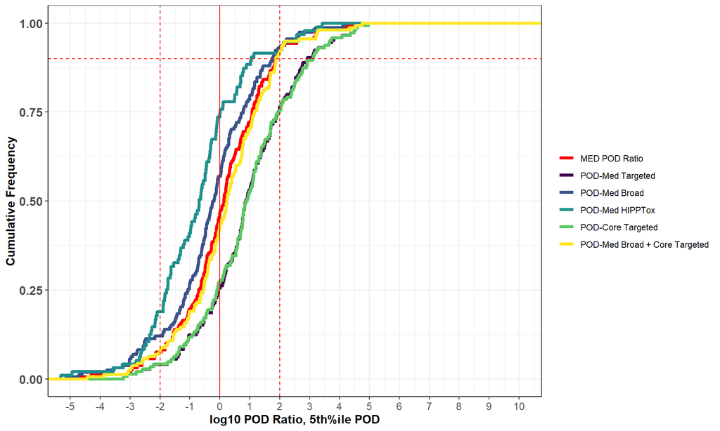

```r
fig.ratio.ecdfa <- ggplot(asnm.tier1.all.ratios.long[Ratio %in% c('pod.ratio5',
                                                  'ratio5.med.target',
                                                  'ratio5.med.broad',
                                                  'ratio5.med.hipptox',
                                                  'ratio5.med.coretarget',
                                                  'ratio5.med.brta')], aes(Ratio.value, color=Ratio))+
  stat_ecdf(geom='step', size=1.5)+
  #scale_y_continuous(trans = 'log10',
  #                   breaks= c(0.01, 0.1,0.2,0.3,0.4,0.5,0.75,1))+
  ylab("Cumulative Frequency") +
  xlab('log10 POD Ratio, 5th%ile POD')+
  theme_bw() +
  theme(
    axis.line = element_line(colour = "black"),
    axis.text = element_text(size=10),
    axis.title = element_text(size=12, face='bold'))+
  theme(axis.text.y = element_text(family = "sans", face = "bold", size=12))+
  theme(legend.position="right", legend.title=element_blank())+
  scale_x_continuous(breaks=seq(-5,10,1)) +
  coord_cartesian(xlim = c(-5, 10)) +
  #scale_color_viridis(discrete=TRUE, name='Ratio Type')+
  scale_colour_manual(breaks=c('pod.ratio5',
                                                  'ratio5.med.target',
                                                  'ratio5.med.broad',
                                                  'ratio5.med.hipptox',
                                                  'ratio5.med.coretarget',
                                                  'ratio5.med.brta'
                               ),
                      values=c("red", "#440154FF", "#3B528BFF", "#21908CFF", "#5DC863FF", "#FDE725FF"),
                      labels=c("MED POD Ratio", "POD-Med Targeted", "POD-Med Broad", "POD-Med HIPPTox", 'POD-Core Targeted','POD-Med Broad + Core Targeted'))+
  geom_vline(xintercept=-2, lty='dashed', color='red')+
  geom_vline(xintercept=2, lty='dashed', color='red')+
  geom_vline(xintercept=0, color='red')+
  geom_hline(yintercept=0.90, lty='dashed', color='red')

fig.ratio.ecdfa
```

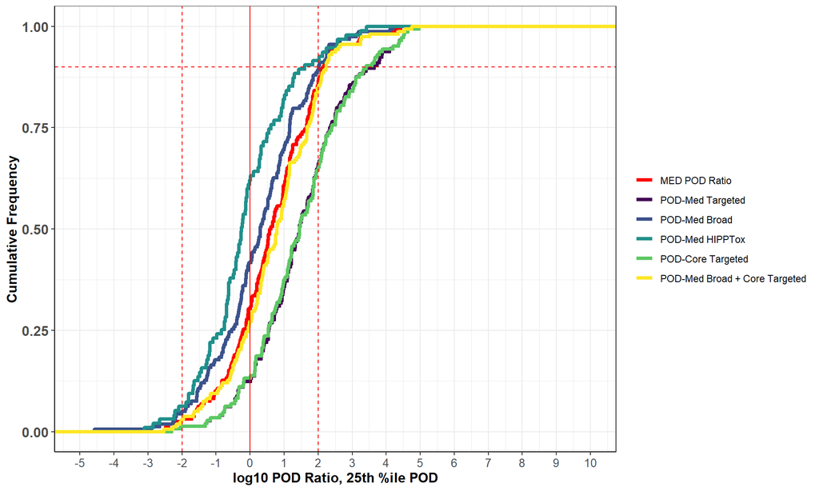

```r
fig.ratio.ecdfb <- ggplot(asnm.tier1.all.ratios.long[Ratio %in% c('pod.ratio25',
                                                  'ratio25.med.target',
                                                  'ratio25.med.broad',
                                                  'ratio25.med.hipptox',
                                                  'ratio25.med.coretarget',
                                                  'ratio25.med.brta')], aes(Ratio.value, color=Ratio))+
  stat_ecdf(geom='step', size=1.5)+
  #scale_y_continuous(trans = 'log10',
  #                   breaks= c(0.01, 0.1,0.2,0.3,0.4,0.5,0.75,1))+
  ylab("Cumulative Frequency") +
  xlab('log10 POD Ratio, 25th %ile POD')+
  theme_bw() +
  theme(
    axis.line = element_line(colour = "black"),
    axis.text = element_text(size=10),
    axis.title = element_text(size=12, face='bold'))+
  theme(axis.text.y = element_text(family = "sans", face = "bold", size=12))+
  theme(legend.position="right", legend.title=element_blank())+
  scale_x_continuous(breaks=seq(-5,10,1)) +
  coord_cartesian(xlim = c(-5, 10)) +
  #scale_color_viridis(discrete=TRUE, name='Ratio Type')+
  scale_colour_manual(breaks=c('pod.ratio25',
                                                  'ratio25.med.target',
                                                  'ratio25.med.broad',
                                                  'ratio25.med.hipptox',
                                                  'ratio25.med.coretarget',
                                                  'ratio25.med.brta'
                               ),
                      values=c("red", "#440154FF", "#3B528BFF", "#21908CFF", "#5DC863FF", "#FDE725FF"),
                      labels=c("MED POD Ratio", "POD-Med Targeted", "POD-Med Broad", "POD-Med HIPPTox", 'POD-Core Targeted','POD-Med Broad + Core Targeted'))+
  geom_vline(xintercept=-2, lty='dashed', color='red')+
  geom_vline(xintercept=2, lty='dashed', color='red')+
  geom_vline(xintercept=0, color='red')+
  geom_hline(yintercept=0.90, lty='dashed', color='red')

fig.ratio.ecdfb
```

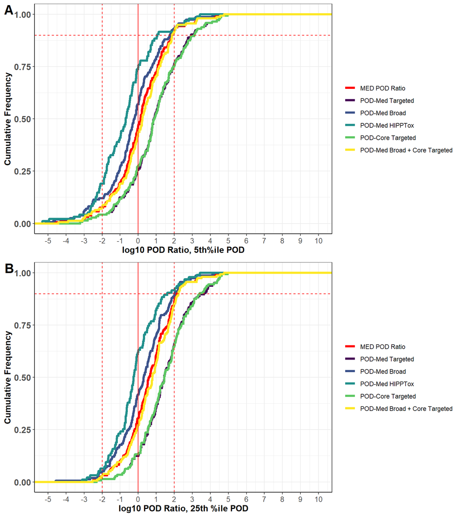

```r
plot_grid(fig.ratio.ecdfa,
          fig.ratio.ecdfb,
          labels = c('A', 'B'), label_size = 18, nrow =2)
```

```r
file.dir <- paste('output/', sep='')
file.name <- paste('/Fig_PODecdfs_comp_', Sys.Date(), '.tiff', sep='')
file.path <- paste(file.dir, file.name, sep='')
dir.create(path=file.dir, showWarnings = FALSE, recursive = TRUE)
tiff(file.path, width=8, height=8, units='in', res=300)

plot_grid(fig.ratio.ecdfa,
          fig.ratio.ecdfb,
          labels = c('A', 'B'), label_size = 18, ncol =1)
dev.off()
```

## 11.1 Make boxplots of the POD ratio distributions

```r
asnm.tier1.all.ratios.long[grep('ratio5',Ratio), Ratio.type := 'POD5p']
asnm.tier1.all.ratios.long[grep('ratio25',Ratio), Ratio.type := 'POD25p']
```

```r
subset.long <- asnm.tier1.all.ratios.long[Ratio %in% c('ratio5.med.hipptox',
                                                       'ratio25.med.hipptox',
                                                   'pod.ratio5',
                                                   'pod.ratio25',
                                                   'ratio5.med.broad',
                                                   'ratio25.med.broad',
                                                   'ratio5.med.brta',
                                                   'ratio25.med.brta',
                                                  'ratio5.med.target',
                                                  'ratio25.med.target',
                                                  'ratio5.med.coretarget',
                                                  'ratio25.med.coretarget'
                                                  )]
subset.long$Ratio <- factor(subset.long$Ratio, levels=c('ratio5.med.hipptox',
                                                       'ratio25.med.hipptox',
                                                   'pod.ratio5',
                                                   'pod.ratio25',
                                                   'ratio5.med.broad',
                                                   'ratio25.med.broad',
                                                   'ratio5.med.brta',
                                                   'ratio25.med.brta',
                                                  'ratio5.med.target',
                                                  'ratio25.med.target',
                                                  'ratio5.med.coretarget',
                                                  'ratio25.med.coretarget'
                                                  ), ordered=TRUE)
```

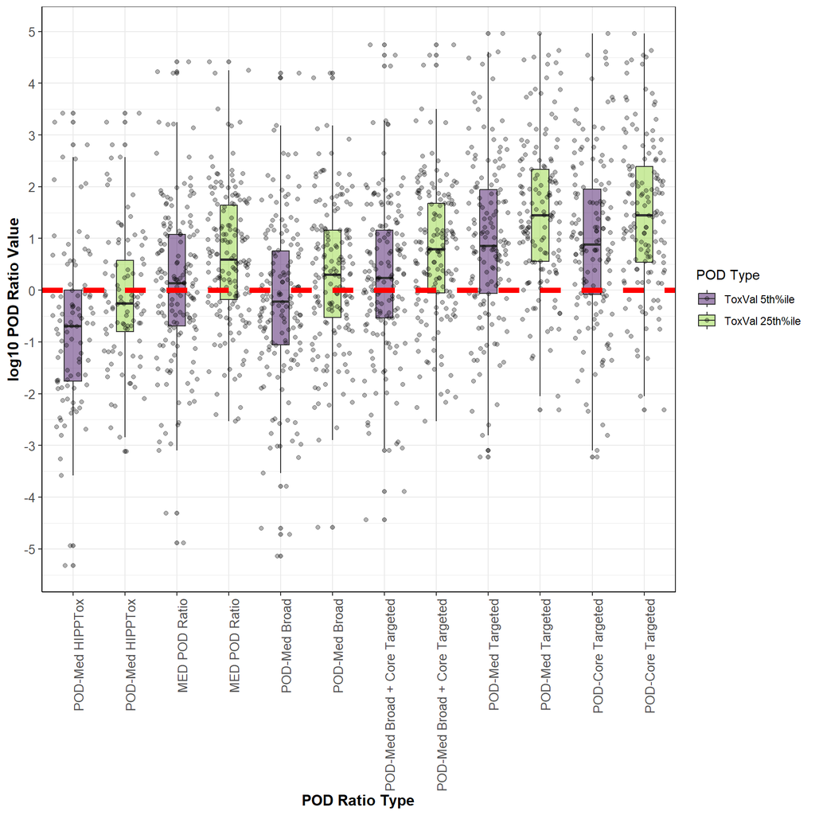

```r
fig.box.pod.ratio <- ggplot(data=subset.long[Ratio %in% c('ratio5.med.hipptox',
                                                       'ratio25.med.hipptox',
                                                   'pod.ratio5',
                                                   'pod.ratio25',
                                                   'ratio5.med.broad',
                                                   'ratio25.med.broad',
                                                   'ratio5.med.brta',
                                                   'ratio25.med.brta',
                                                  'ratio5.med.target',
                                                  'ratio25.med.target',
                                                  'ratio5.med.coretarget',
                                                  'ratio25.med.coretarget'
                                                  )],
           aes(y=Ratio.value, x=factor(Ratio), fill=Ratio.type))+
      geom_boxplot(alpha=0.5,width = 0.33)+
      geom_jitter(alpha=0.3, color='black')+
      scale_y_continuous(breaks=seq(-6, 6, 1))+
  scale_fill_manual(name='POD Type',
                    values=c('#481567FF','#95D840FF'),
                     labels=c('ToxVal 5th%ile', 'ToxVal 25th%ile'),
                     breaks = c('POD5p','POD25p'))+
  scale_x_discrete(labels=c('POD-Med HIPPTox', 'POD-Med HIPPTox',
                            "MED POD Ratio", "MED POD Ratio",
                            "POD-Med Broad", "POD-Med Broad",
                            'POD-Med Broad + Core Targeted', 'POD-Med Broad + Core Targeted',
                            "POD-Med Targeted", "POD-Med Targeted",
                            'POD-Core Targeted', 'POD-Core Targeted'))+
      xlab('POD Ratio Type') +
      ylab('log10 POD Ratio Value')+
      theme_bw() +
      theme(
        axis.line = element_line(colour = "black"),
        axis.text = element_text(size=10),
        axis.title = element_text(size=12, face='bold'))+
      theme(axis.text.x = element_text(family = "sans", size=10, angle=90, hjust=1))+
      theme(legend.position="right")+
  geom_hline(yintercept = 0, lty='dashed', color='red', size=2)

fig.box.pod.ratio
```

```r
file.dir <- paste('output/', sep='')
file.name <- paste('/Fig_PODratiobox_comp_', Sys.Date(), '.tiff', sep='')
file.path <- paste(file.dir, file.name, sep='')
dir.create(path=file.dir, showWarnings = FALSE, recursive = TRUE)
tiff(file.path, width=8, height=6, units='in', res=300)
fig.box.pod.ratio
dev.off()
```

# 12 Update Table 2 with Ratio Counts

```r
# get Inf to NA in table
for (j in 1:ncol(asnm.tier1.all.ratios)) set(asnm.tier1.all.ratios, which(is.infinite(asnm.tier1.all.ratios[[j]])), j, NA)

## reduce table to the Table 2 outputs
#dput(colnames(asnm.tier1.all.ratios))
non_NA_counts <- as.data.frame(sapply(asnm.tier1.all.ratios, function(x) sum(!is.na(x))))
asnm.ratio.counts <- as.data.table(asnm.tier1.all.ratios[,c("min.aed50", # AED50 values
                                                            "med.aed50",
                                                            "min.broad.aed50",
                                                            "min.targeted.aed50",
                                                            "med.broad.aed50",
                                                            "med.targeted.aed50",
                                                            "aed50.atg",
                                                            "aed50.bsk",
                                                            "aed50.nvs",
                                                            "aed50.stm",
                                                            "aed50.htpp.u2os",
                                                            "aed50.httr.heparg",
                                                            "aed50.httr.mcf7",
                                                            "aed50.httr.u2os",
                                                            "aed50.astar.beas2b",
                                                            "aed50.astar.hepg2",
                                                            "aed50.astar.hek293",
                                                            "mlr.toxval5.aed50",
                                                            "mlr.toxval25.aed50",

                                                            "log.repdose.any.5th", #ToxVal+ECHA in vivo values
                                                            "log.repdose.any.10th",
                                                            "log.repdose.any.15th",
                                                            "log.repdose.any.20th",
                                                            "log.repdose.any.25th",
                                                            "log.repdose.any.30th",

                                                            "pod.min.ratio5", # Battery Min POD ratios
                                                            "pod.min.ratio10",
                                                            "pod.min.ratio15",
                                                            "pod.min.ratio20",
                                                            "pod.min.ratio25",
                                                            "pod.min.ratio30",

                                                            "pod.ratio5", # Battery Med POD ratios
                                                            "pod.ratio10",
                                                            "pod.ratio15",
                                                            "pod.ratio20",
                                                            "pod.ratio25",
                                                            "pod.ratio30",

                                                            "ratio5.min.broad", # Min Broad POD ratios
                                                            "ratio10.min.broad",
                                                            "ratio15.min.broad",
                                                            "ratio20.min.broad",
                                                            "ratio25.min.broad",
                                                            "ratio30.min.broad",

                                                            "ratio5.min.target", # Min Targeted POD ratios
                                                            "ratio10.min.target",
                                                            "ratio15.min.target",
                                                            "ratio20.min.target",
                                                            "ratio25.min.target",
                                                            "ratio30.min.target",

                                                            "ratio5.med.broad", # Med Broad POD ratios
                                                            "ratio10.med.broad",
                                                            "ratio15.med.broad",
                                                            "ratio20.med.broad",
                                                            "ratio25.med.broad",
                                                            "ratio30.med.broad",

                                                            "ratio5.med.target", # Med targeted pod ratios
                                                            "ratio10.med.target",
                                                            "ratio15.med.target",
                                                            "ratio20.med.target",
                                                            "ratio25.med.target",
                                                            "ratio30.med.target",

                                                            "ratio5.atg", # individual assays
                                                            "ratio5.biomap",
                                                            "ratio5.nvs",
                                                            "ratio5.stm",

                                                            "ratio5.htpp.u2os",
                                                            "ratio5.httr.heparg",
                                                            "ratio5.httr.mcf7",
                                                            "ratio5.httr.u2os",

                                                            "ratio5.hipptox.beas2b",
                                                            "ratio5.hipptox.hepg2",
                                                            "ratio5.hipptox.hk2",


                                                            "ratio5.mlr5", #MLR models
                                                            "ratio25.mlr25",

                                                            "ratio5.med.coretarget", # other ratios from figures - not in table2
                                                            "ratio5.med.hipptox",
                                                            "ratio5.med.brta",
                                                            "ratio25.med.coretarget",
                                                            "ratio25.med.hipptox",
                                                            "ratio25.med.brta"
                                                            )])
```

```r
counts_ratios_notNA <- as.data.frame(sapply(asnm.ratio.counts, function(x) sum(!is.na(x))))
count_ratios_gte0 <- as.data.frame(sapply(asnm.ratio.counts, function(x) sum(x >=0, na.rm=TRUE)))
count_ratios_win2 <- as.data.frame(sapply(asnm.ratio.counts, function(x) sum(x >= -2 & x<=2, na.rm=TRUE)))
count_ratios_gteneg2 <- as.data.frame(sapply(asnm.ratio.counts, function(x) sum(x >= -2, na.rm=TRUE)))

asnm.summary.counts <- cbind.data.frame(counts_ratios_notNA,
                                                      count_ratios_gte0,
                                                      count_ratios_win2,
                                        count_ratios_gteneg2)

asnm.summary.counts <- rownames_to_column(asnm.summary.counts, var="RatioType")
asnm.summary.counts <- as.data.table(asnm.summary.counts)
setnames(asnm.summary.counts, c(2,3,4,5), c('count','count-gte0','count-win2', 'count-gteneg2'))

asnm.summary.counts[,podratiogt0 := round(((count_ratios_gte0/158)*100),1)]
asnm.summary.counts[,podratiowin2 := round(((count_ratios_win2/158)*100),1)]
asnm.summary.counts[,podratiogteneg2 := round(((count_ratios_gteneg2/158)*100),1)]
```

Merge with performance Table 2.

```r
tbl2.part2 <- asnm.summary.counts[-c(1:25,75:80),]

nr <- max(nrow(models_performance_summary), nrow(tbl2.part2))
tbl2 <- cbind(models_performance_summary[1:nr, ], tbl2.part2[1:nr, ])
```

Write files

```r
list_data <- list("Table2" = as.data.frame(tbl2),
                  "All-pod-ratios" = as.data.frame(asnm.tier1.all.ratios))

write.xlsx(list_data, './output/table2_podratios_29nov2024.xlsx')
```